# Time Series Project

```r
f = fore.arima.wge(x,d=1,phi=est$phi,theta=est$theta,n.ahead=h.short,lastn=TRUE)
```

```
## y.arma 0.5 -0.3 -0.1 0.1 0 0.3 -0.1 0 -0.3 0.5 -0.1 -0.1 -0.4 0.8 0.2 -0.6 0.1 0.9 -0.4 0.1 0 0.3 -0.3 0.1 -0.3 0.3 -0.4 -0.4 0.1 0 -0.4 0.2 0 0.1 -0.4 0.2 0 0 -0.5 0 0 -0.2 -0.4 0.1 0.2 0 0.1 -0.1 0 0.4 -0.1 -0.4 0 0.3 -0.2 0.1 -0.1 0.3 -0.3 0.2 -0.3 0.3 0.1 -0.2 0 0.3 0 -0.2 -0.1 0.4 0.1 -0.2 0…
```

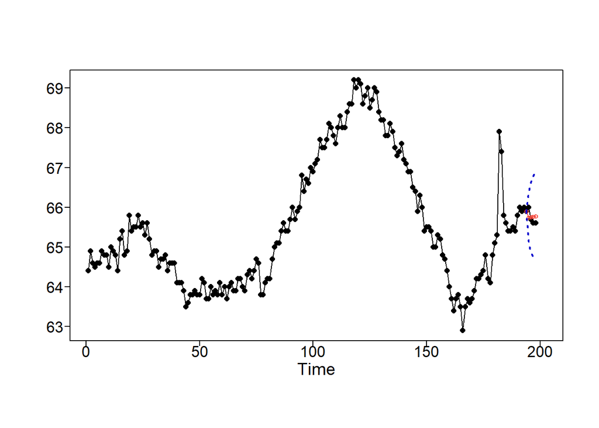

```r
ase = mean((x[(l-h.short+1):l]-f$f)^2)
ase # 0.03083697
```

```
## [1] 0.03083697
```

```r
f = fore.arima.wge(x,d=1,phi=est$phi,theta=est$theta,n.ahead=h.long,lastn=TRUE)
```

```
## y.arma 0.5 -0.3 -0.1 0.1 0 0.3 -0.1 0 -0.3 0.5 -0.1 -0.1 -0.4 0.8 0.2 -0.6 0.1 0.9 -0.4 0.1 0 0.3 -0.3 0.1 -0.3 0.3 -0.4 -0.4 0.1 0 -0.4 0.2 0 0.1 -0.4 0.2 0 0 -0.5 0 0 -0.2 -0.4 0.1 0.2 0 0.1 -0.1 0 0.4 -0.1 -0.4 0 0.3 -0.2 0.1 -0.1 0.3 -0.3 0.2 -0.3 0.3 0.1 -0.2 0 0.3 0 -0.2 -0.1 0.4 0.1 -0.2 0…
```

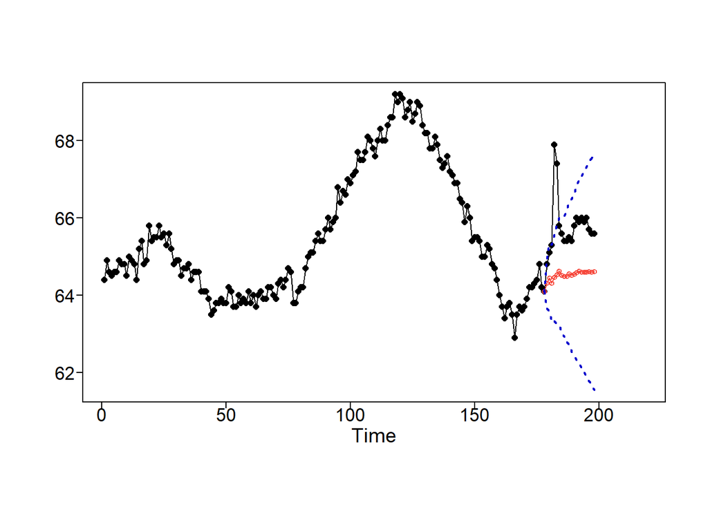

```r
ase = mean((x[(l-h.long+1):l]-f$f)^2)
ase # 2.077416
```

```
## [1] 2.077416
```

This model has a short term ASE of 0.031 and a long term ASE of 2.08.

Next will compare this to an ARMA model.

```r
aic5.wge(x,p=0:12,q=0:2,type='aic') # 9/1 best
```

```
## ---------WORKING... PLEASE WAIT...
##
##
## Five Smallest Values of  aic
##     p    q        aic
##     9    1  -2.144284
##     9    2  -2.134332
##    10    0  -2.123071
##     9    0  -2.122279
##    12    2  -2.116436
```

The model it chose had p = 9 and q = 1.

```r
est = est.arma.wge(x,p=9,q=1)
```

```
##
##
## Coefficients of AR polynomial:
## 1.6768 -0.8806 0.4076 -0.1012 -0.3757 0.4520 -0.2987 0.3697 -0.2608
##
##                            AR Factor Table
## Factor                 Roots                Abs Recip    System Freq
## 1-1.9534B+0.9571B^2    1.0204+-0.0589i      0.9783       0.0092
## 1-1.3559B+0.7452B^2    0.9098+-0.7171i      0.8632       0.1062
## 1+0.8617B             -1.1605               0.8617       0.5000
## 1-0.0469B+0.7004B^2    0.0335+-1.1944i      0.8369       0.2455
## 1+0.8177B+0.6059B^2   -0.6748+-1.0932i      0.7784       0.3380
##
##
##
##
## Coefficients of MA polynomial:
## 0.7795
##
##                               MA FACTOR TABLE
## Factor                 Roots                Abs Recip    System Freq
## 1-0.7795B              1.2828               0.7795       0.0000
##
##
```

```r
f = fore.arima.wge(x,phi=est$phi,theta=est$theta,n.ahead=h.short,lastn=TRUE)
```

```
## y.arma 64.4 64.9 64.6 64.5 64.6 64.6 64.9 64.8 64.8 64.5 65 64.9 64.8 64.4 65.2 65.4 64.8 64.9 65.8 65.4 65.5 65.5 65.8 65.5 65.6 65.3 65.6 65.2 64.8 64.9 64.9 64.5 64.7 64.7 64.8 64.4 64.6 64.6 64.6 64.1 64.1 64.1 63.9 63.5 63.6 63.8 63.8 63.9 63.8 63.8 64.2 64.1 63.7 63.7 64 63.8 63.9 63.8 64.1…
```

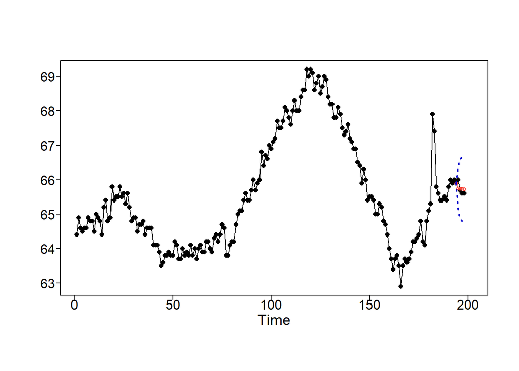

```r
ase = mean((x[(l-h.short+1):l]-f$f)^2)
ase # 0.02468854
```

```
## [1] 0.02468854
```

```r
f = fore.arima.wge(x,phi=est$phi,theta=est$theta,n.ahead=h.long,lastn=TRUE)
```

```
## y.arma 64.4 64.9 64.6 64.5 64.6 64.6 64.9 64.8 64.8 64.5 65 64.9 64.8 64.4 65.2 65.4 64.8 64.9 65.8 65.4 65.5 65.5 65.8 65.5 65.6 65.3 65.6 65.2 64.8 64.9 64.9 64.5 64.7 64.7 64.8 64.4 64.6 64.6 64.6 64.1 64.1 64.1 63.9 63.5 63.6 63.8 63.8 63.9 63.8 63.8 64.2 64.1 63.7 63.7 64 63.8 63.9 63.8 64.1…
```

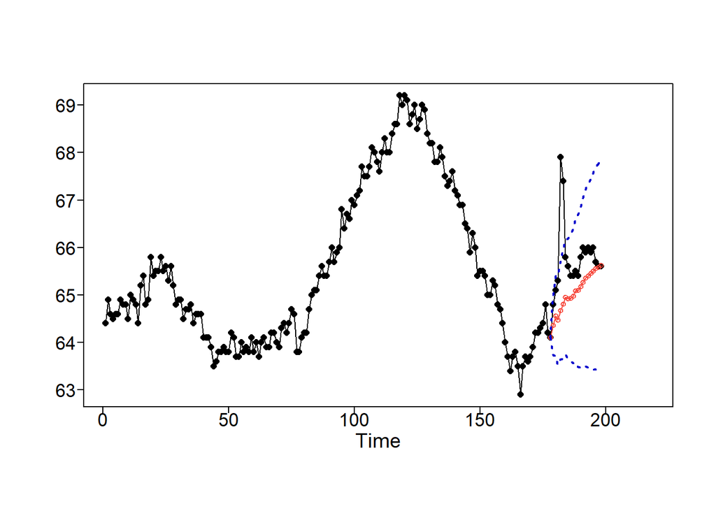

```r
ase = mean((x[(l-h.long+1):l]-f$f)^2)
ase # 1.108741
```

```
## [1] 1.108741
```

This model had better ASE values with 0.025 for short term and 1.11 for long term. This will be the predictions we use for our MLR and MLP models.

```r
fed_housing_data_short = fed_housing_data
fed_housing_data_long = fed_housing_data
x = fed_housing_data$Ownership_Rate
est = est.arma.wge(x,p=9,q=1)
```

```
##
##
## Coefficients of AR polynomial:
## 1.6768 -0.8806 0.4076 -0.1012 -0.3757 0.4520 -0.2987 0.3697 -0.2608
##
##                            AR Factor Table
## Factor                 Roots                Abs Recip    System Freq
## 1-1.9534B+0.9571B^2    1.0204+-0.0589i      0.9783       0.0092
## 1-1.3559B+0.7452B^2    0.9098+-0.7171i      0.8632       0.1062
## 1+0.8617B             -1.1605               0.8617       0.5000
## 1-0.0469B+0.7004B^2    0.0335+-1.1944i      0.8369       0.2455
## 1+0.8177B+0.6059B^2   -0.6748+-1.0932i      0.7784       0.3380
##
##
##
##
## Coefficients of MA polynomial:
## 0.7795
##
##                               MA FACTOR TABLE
## Factor                 Roots                Abs Recip    System Freq
## 1-0.7795B              1.2828               0.7795       0.0000
##
##
```

```r
f = fore.arima.wge(x,phi=est$phi,theta=est$theta,n.ahead=h.short,lastn=TRUE)
```

```
## y.arma 64.4 64.9 64.6 64.5 64.6 64.6 64.9 64.8 64.8 64.5 65 64.9 64.8 64.4 65.2 65.4 64.8 64.9 65.8 65.4 65.5 65.5 65.8 65.5 65.6 65.3 65.6 65.2 64.8 64.9 64.9 64.5 64.7 64.7 64.8 64.4 64.6 64.6 64.6 64.1 64.1 64.1 63.9 63.5 63.6 63.8 63.8 63.9 63.8 63.8 64.2 64.1 63.7 63.7 64 63.8 63.9 63.8 64.1…
```

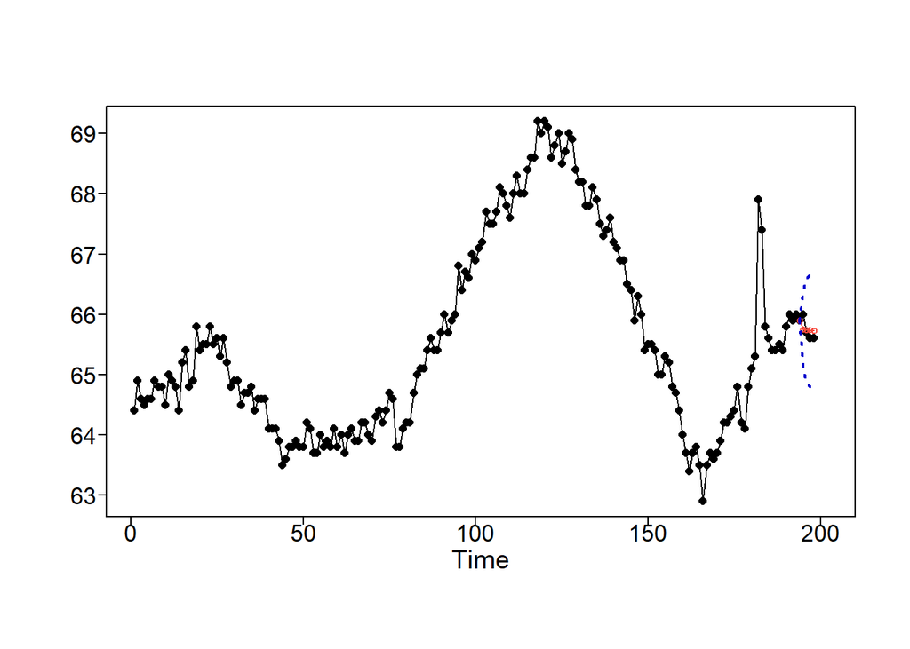

```r
hor.pred.short = f$f
f = fore.arima.wge(x,phi=est$phi,theta=est$theta,n.ahead=h.long,lastn=TRUE)
```

```
## y.arma 64.4 64.9 64.6 64.5 64.6 64.6 64.9 64.8 64.8 64.5 65 64.9 64.8 64.4 65.2 65.4 64.8 64.9 65.8 65.4 65.5 65.5 65.8 65.5 65.6 65.3 65.6 65.2 64.8 64.9 64.9 64.5 64.7 64.7 64.8 64.4 64.6 64.6 64.6 64.1 64.1 64.1 63.9 63.5 63.6 63.8 63.8 63.9 63.8 63.8 64.2 64.1 63.7 63.7 64 63.8 63.9 63.8 64.1…
```

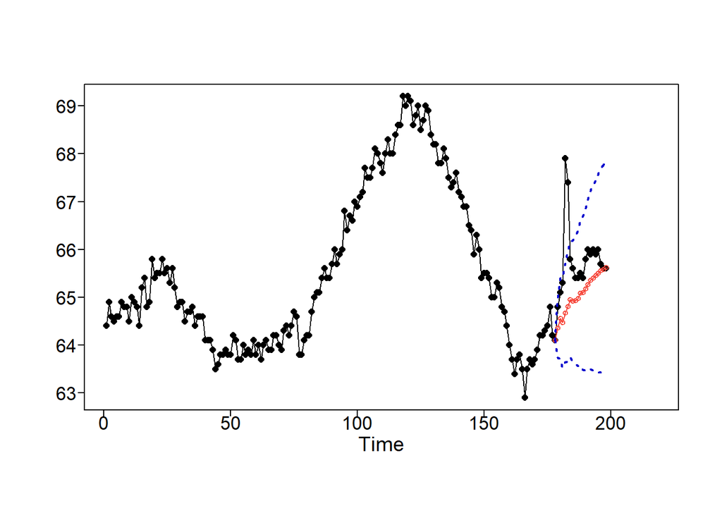

```r
hor.pred.long = f$f
fed_housing_data_short$Ownership_Rate[(l-h.short+1):l] = hor.pred.short
fed_housing_data_long$Ownership_Rate[(l-h.long+1):l] = hor.pred.long
```

## Housing Units Completed

The Housing Units Completed variable looked like either an ARMA or an ARIMA(p,1,q) might be appropriate for forecasting.

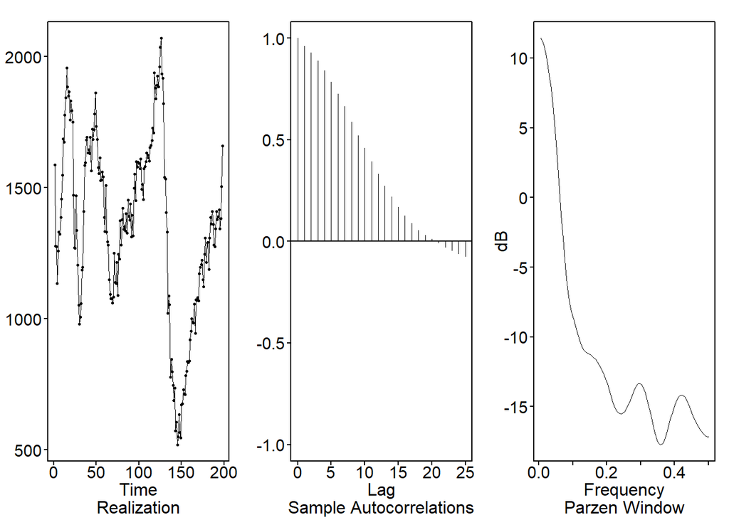

```
## $xbar
## [1] 1354.924
##
## $autplt
##  [1]  1.000000000  0.959798082  0.927757828  0.887546260  0.839449796
##  [6]  0.785021406  0.724421795  0.663945462  0.587584415  0.521735598
## [11]  0.459327920  0.391804222  0.331038625  0.272988776  0.219171898
## [16]  0.167685853  0.124990699  0.088571013  0.054233289  0.031115266
## [21]  0.011815053 -0.006148206 -0.028654674 -0.043678086 -0.059390137
## [26] -0.072592499
##
## $freq
##  [1] 0.005050505 0.010101010 0.015151515 0.020202020 0.025252525 0.030303030
##  [7] 0.035353535 0.040404040 0.045454545 0.050505051 0.055555556 0.060606061
## [13] 0.065656566 0.070707071 0.075757576 0.080808081 0.085858586 0.090909091
```

[output cut: 33 more lines]

```r
x = fed_housing_data$Housing_Units_Completed
plotts.sample.wge(x)
```

```r
d = artrans.wge(x,1)
```

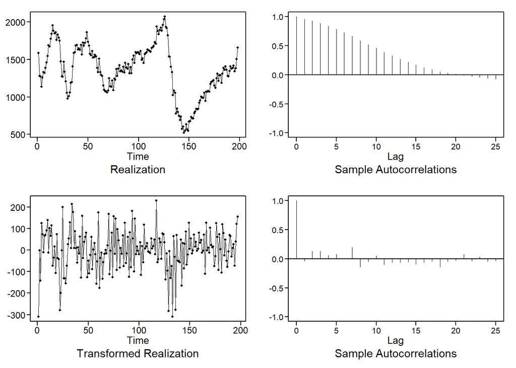

However, this looks like the autocorrelations dampen even less slowly than the Home Ownership Rate, meaning that an ARIMA(p,1,q) model would be even less appropriate. Since we chose the ARMA model for Home Ownership Rate over the ARIMA model. We will just focus on the ARMA model for Housing Units Complete.

```r
aic5.wge(x,p=0:10,q=0:1,type='aic') # 10/0 best
```

```
## ---------WORKING... PLEASE WAIT...
##
##
## Five Smallest Values of  aic
##     p    q        aic
##    10    0   9.024872
##     9    0   9.025447
##     9    1   9.028069
##     8    0   9.028335
##     8    1   9.032021
```

```r
est = est.ar.wge(x,p=10)
```

```
##
##
## Coefficients of AR polynomial:
## 0.8984 0.1900 0.0176 -0.0870 0.0137 -0.0379 0.1724 -0.3410 0.0211 0.0961
##
##                            AR Factor Table
## Factor                 Roots                Abs Recip    System Freq
## 1-1.7434B+0.7704B^2    1.1315+-0.1333i      0.8777       0.0187
## 1+0.4915B+0.7394B^2   -0.3323+-1.1144i      0.8599       0.2961
## 1+1.5034B+0.7169B^2   -1.0486+-0.5435i      0.8467       0.4239
## 1-0.8325B+0.6888B^2    0.6043+-1.0424i      0.8300       0.1664
## 1-0.7644B              1.3083               0.7644       0.0000
## 1+0.4469B             -2.2378               0.4469       0.5000
##
##
```

```r
f = fore.arima.wge(x,phi=est$phi,n.ahead=h.short,lastn=TRUE)
```

```
## y.arma 1588 1278 1276 1134 1258 1332 1322 1388 1457 1548 1687 1675 1777 1843 1957 1885 1850 1866 1759 1832 1794 1751 1472 1272 1270 1469 1337 1206 1052 979 1006 1059 1187 1197 1410 1586 1595 1683 1692 1633 1646 1630 1693 1565 1723 1685 1722 1782 1862 1735 1685 1577 1554 1615 1527 1529 1561 1542 1…
```

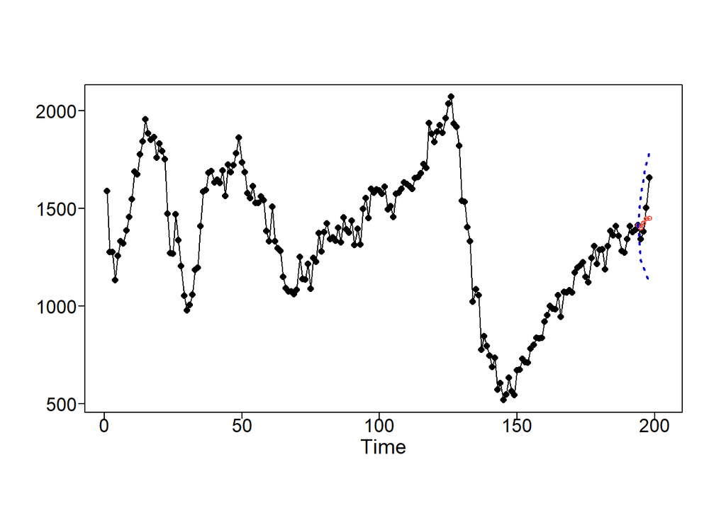

```r
ase = mean((x[(l-h.short+1):l]-f$f)^2)/1e3
ase # 12.98288
```

```
## [1] 12.98288
```

```r
f = fore.arima.wge(x,phi=est$phi,n.ahead=h.long,lastn=TRUE)
```

```
## y.arma 1588 1278 1276 1134 1258 1332 1322 1388 1457 1548 1687 1675 1777 1843 1957 1885 1850 1866 1759 1832 1794 1751 1472 1272 1270 1469 1337 1206 1052 979 1006 1059 1187 1197 1410 1586 1595 1683 1692 1633 1646 1630 1693 1565 1723 1685 1722 1782 1862 1735 1685 1577 1554 1615 1527 1529 1561 1542 1…
```

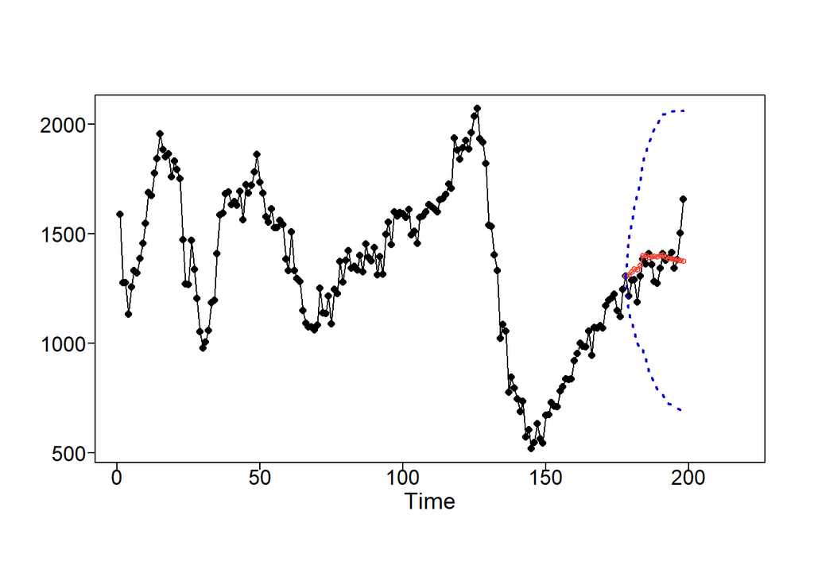

```r
ase = mean((x[(l-h.long+1):l]-f$f)^2)/1e3
ase # 8.546039
```

```
## [1] 8.546039
```

This gives a short term ASE of 13.0k and a long term ASE of 8.5k. Playing around with some of the other output from the aic5 output showed that an ARMA(9,1) model does slightly better for long term predictions and slightly worse for short term predictions.

```r
est = est.arma.wge(x,p=9,q=1)
```

```
##
##
## Coefficients of AR polynomial:
## 1.4066 -0.2813 -0.0540 -0.1068 0.0604 -0.0496 0.1985 -0.4289 0.2277
##
##                            AR Factor Table
## Factor                 Roots                Abs Recip    System Freq
## 1-1.7319B+0.7686B^2    1.1267+-0.1778i      0.8767       0.0249
## 1-0.8710B              1.1481               0.8710       0.0000
## 1+1.5502B+0.7380B^2   -1.0502+-0.5020i      0.8591       0.4290
## 1+0.5020B+0.6999B^2   -0.3586+-1.1402i      0.8366       0.2985
## 1-0.8558B+0.6584B^2    0.6499+-1.0471i      0.8114       0.1616
##
##
##
##
## Coefficients of MA polynomial:
## 0.5043
##
##                               MA FACTOR TABLE
## Factor                 Roots                Abs Recip    System Freq
## 1-0.5043B              1.9829               0.5043       0.0000
##
##
```

```r
f = fore.arima.wge(x,phi=est$phi,theta=est$theta,n.ahead=h.short,lastn=TRUE)
```

```
## y.arma 1588 1278 1276 1134 1258 1332 1322 1388 1457 1548 1687 1675 1777 1843 1957 1885 1850 1866 1759 1832 1794 1751 1472 1272 1270 1469 1337 1206 1052 979 1006 1059 1187 1197 1410 1586 1595 1683 1692 1633 1646 1630 1693 1565 1723 1685 1722 1782 1862 1735 1685 1577 1554 1615 1527 1529 1561 1542 1…
```

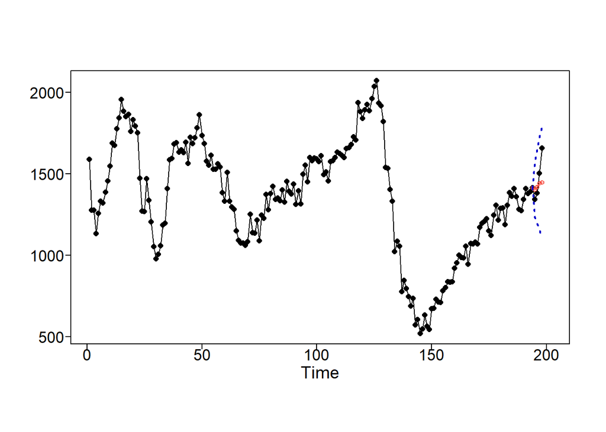

```r
ase = mean((x[(l-h.short+1):l]-f$f)^2)/1e3
ase # 13.44075
```

```
## [1] 13.44075
```

```r
f = fore.arima.wge(x,phi=est$phi,theta=est$theta,n.ahead=h.long,lastn=TRUE)
```

```
## y.arma 1588 1278 1276 1134 1258 1332 1322 1388 1457 1548 1687 1675 1777 1843 1957 1885 1850 1866 1759 1832 1794 1751 1472 1272 1270 1469 1337 1206 1052 979 1006 1059 1187 1197 1410 1586 1595 1683 1692 1633 1646 1630 1693 1565 1723 1685 1722 1782 1862 1735 1685 1577 1554 1615 1527 1529 1561 1542 1…
```

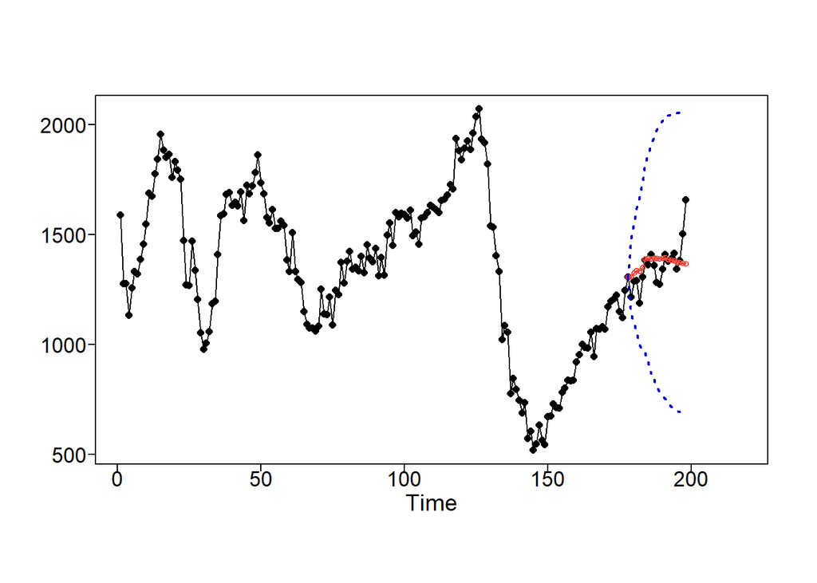

```r
ase = mean((x[(l-h.long+1):l]-f$f)^2)/1e3
ase # 8.516217
```

```
## [1] 8.516217
```

We will proceed with the ARMA(9,1) forecast for our future models that use exogenous variables.

```r
x = fed_housing_data$Housing_Units_Completed
est = est.arma.wge(x,p=9,q=1)
```

```
##
##
## Coefficients of AR polynomial:
## 1.4066 -0.2813 -0.0540 -0.1068 0.0604 -0.0496 0.1985 -0.4289 0.2277
##
##                            AR Factor Table
## Factor                 Roots                Abs Recip    System Freq
## 1-1.7319B+0.7686B^2    1.1267+-0.1778i      0.8767       0.0249
## 1-0.8710B              1.1481               0.8710       0.0000
## 1+1.5502B+0.7380B^2   -1.0502+-0.5020i      0.8591       0.4290
## 1+0.5020B+0.6999B^2   -0.3586+-1.1402i      0.8366       0.2985
## 1-0.8558B+0.6584B^2    0.6499+-1.0471i      0.8114       0.1616
##
##
##
##
## Coefficients of MA polynomial:
## 0.5043
##
##                               MA FACTOR TABLE
## Factor                 Roots                Abs Recip    System Freq
## 1-0.5043B              1.9829               0.5043       0.0000
##
##
```

```r
f = fore.arima.wge(x,phi=est$phi,theta=est$theta,n.ahead=h.short,lastn=TRUE)
```

```
## y.arma 1588 1278 1276 1134 1258 1332 1322 1388 1457 1548 1687 1675 1777 1843 1957 1885 1850 1866 1759 1832 1794 1751 1472 1272 1270 1469 1337 1206 1052 979 1006 1059 1187 1197 1410 1586 1595 1683 1692 1633 1646 1630 1693 1565 1723 1685 1722 1782 1862 1735 1685 1577 1554 1615 1527 1529 1561 1542 1…
```

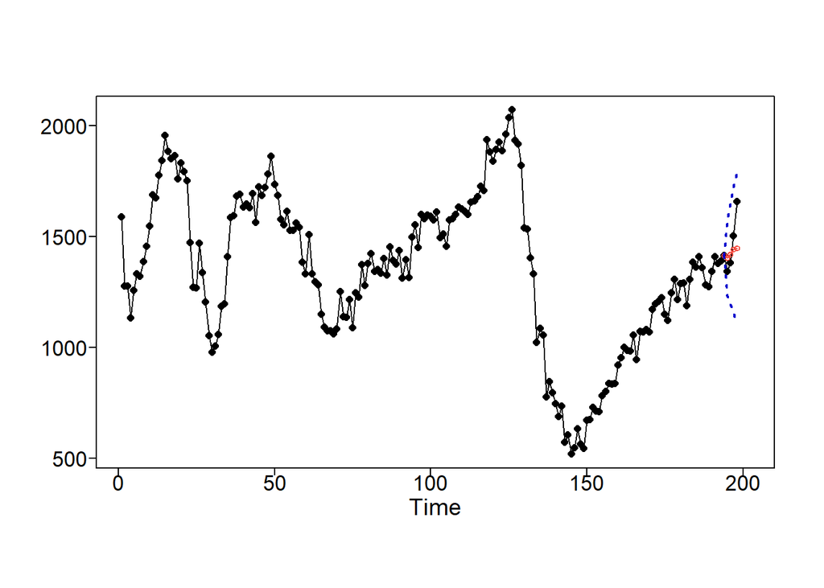

```r
huc.pred.short = f$f
f = fore.arima.wge(x,phi=est$phi,theta=est$theta,n.ahead=h.long,lastn=TRUE)
```

```
## y.arma 1588 1278 1276 1134 1258 1332 1322 1388 1457 1548 1687 1675 1777 1843 1957 1885 1850 1866 1759 1832 1794 1751 1472 1272 1270 1469 1337 1206 1052 979 1006 1059 1187 1197 1410 1586 1595 1683 1692 1633 1646 1630 1693 1565 1723 1685 1722 1782 1862 1735 1685 1577 1554 1615 1527 1529 1561 1542 1…
```

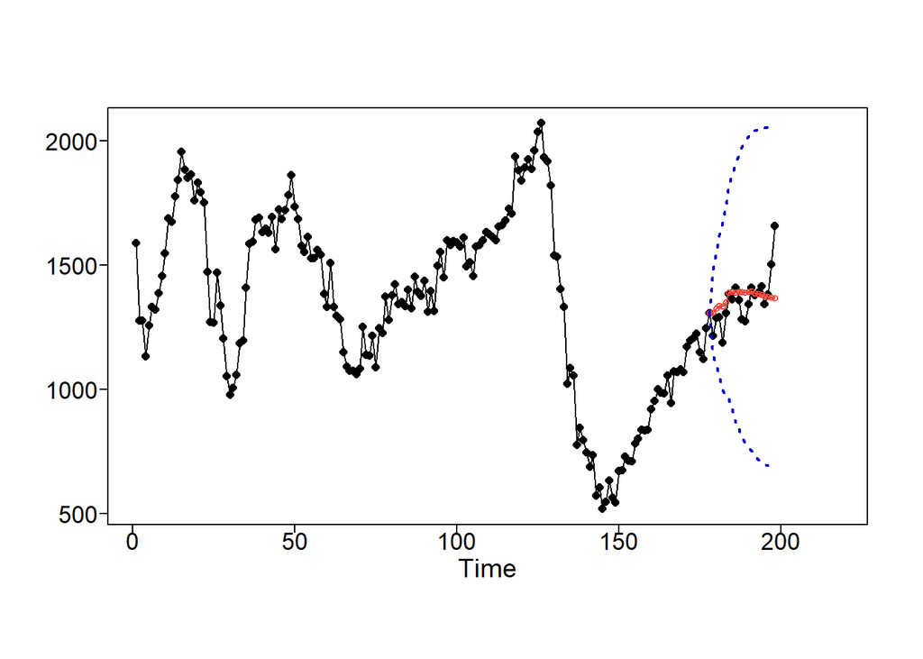

```r
huc.pred.long = f$f
fed_housing_data_short$Housing_Units_Completed[(l-h.short+1):l] = huc.pred.short
fed_housing_data_long$Housing_Units_Completed[(l-h.long+1):l] = huc.pred.long
```

## Supply of New Houses

Similar to Housing Units Completed, an ARMA model seems like it would be most appropriate for Supply of New Houses.

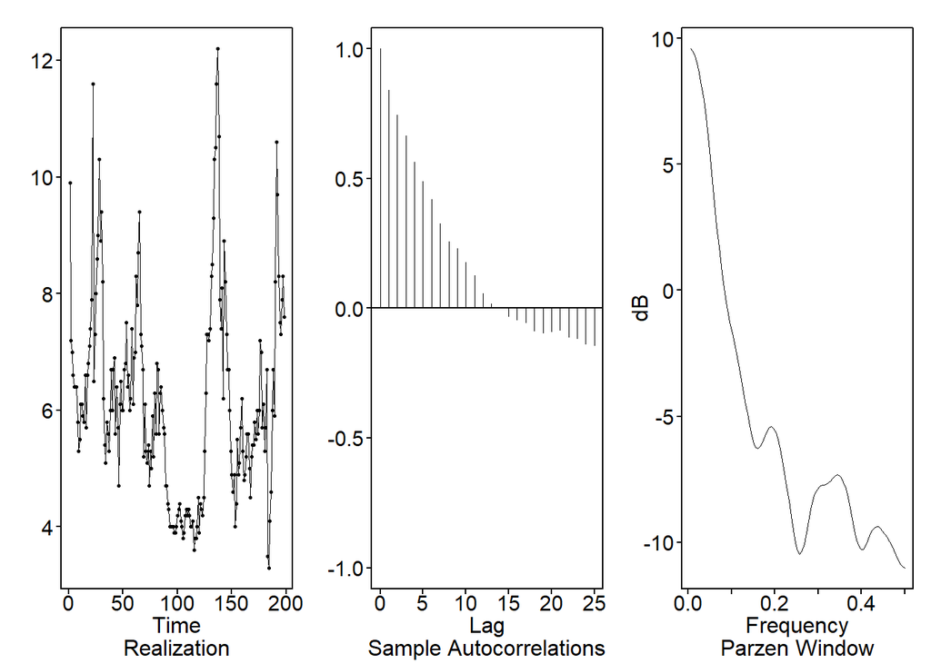

```
## $xbar
## [1] 6.167172
##
## $autplt
##  [1]  1.000000000  0.840571774  0.745101265  0.663968698  0.563328441
##  [6]  0.489741871  0.419594057  0.325865642  0.257517222  0.230333020
## [11]  0.176617503  0.124718033  0.057267731  0.015708696  0.002656971
## [16] -0.031243001 -0.045540921 -0.054571142 -0.086637135 -0.094349258
## [21] -0.090844434 -0.085823390 -0.112309986 -0.115799497 -0.138576373
## [26] -0.143176298
##
## $freq
##  [1] 0.005050505 0.010101010 0.015151515 0.020202020 0.025252525 0.030303030
##  [7] 0.035353535 0.040404040 0.045454545 0.050505051 0.055555556 0.060606061
## [13] 0.065656566 0.070707071 0.075757576 0.080808081 0.085858586 0.090909091
```

[output cut: 33 more lines]

```r
x = fed_housing_data$Supply_New_Houses
plotts.sample.wge(x)
```

```r
d = artrans.wge(x,1)
```

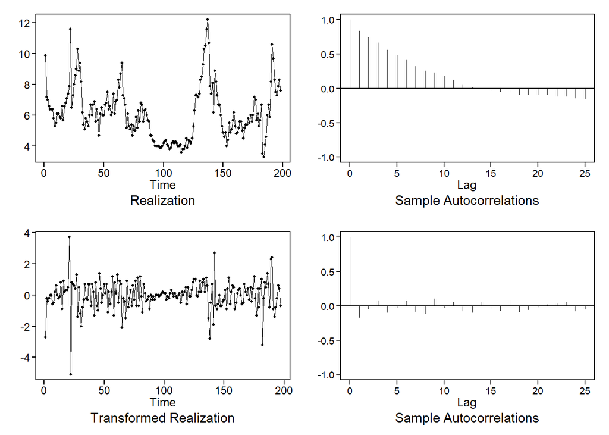

```r
aic5.wge(x,p=0:4,q=0:1,type='aic') # 1/0 best
```

```
## ---------WORKING... PLEASE WAIT...
##
##
## Five Smallest Values of  aic
##     p    q        aic
##     1    0 -0.1975496
##     1    1 -0.1970961
##     2    0 -0.1970576
##     3    1 -0.1966637
##     4    0 -0.1912306
```

```r
est = est.ar.wge(x,p=1)
```

```
##
##
## Coefficients of AR polynomial:
## 0.8594
##
##                            AR Factor Table
## Factor                 Roots                Abs Recip    System Freq
## 1-0.8594B              1.1636               0.8594       0.0000
##
##
```

```r
f = fore.arima.wge(x,phi=est$phi,n.ahead=h.short,lastn=TRUE)
```

```
## y.arma 9.9 7.2 7 6.6 6.4 6.4 6.4 5.8 5.3 5.5 6.1 6.1 5.9 5.8 6.6 5.7 6.6 6.8 7.1 7.4 7.9 11.6 6.5 7.3 8 8.6 9 10.3 8.9 9.4 8.2 6.2 5.4 5.1 5.8 5.6 5.3 6 6.7 6 6.7 6.9 5.6 6.4 5.7 4.7 6.1 6.5 6 6 6.7 6.8 7.5 6.4 6.6 6 6.2 7.4 6.1 6.9 7 8.3 7.8 8.7 9.4 7.3 7.1 6.7 5.2 6.1 5.3 5.1 5.4 4.7 5.3 5 5.9 …
```

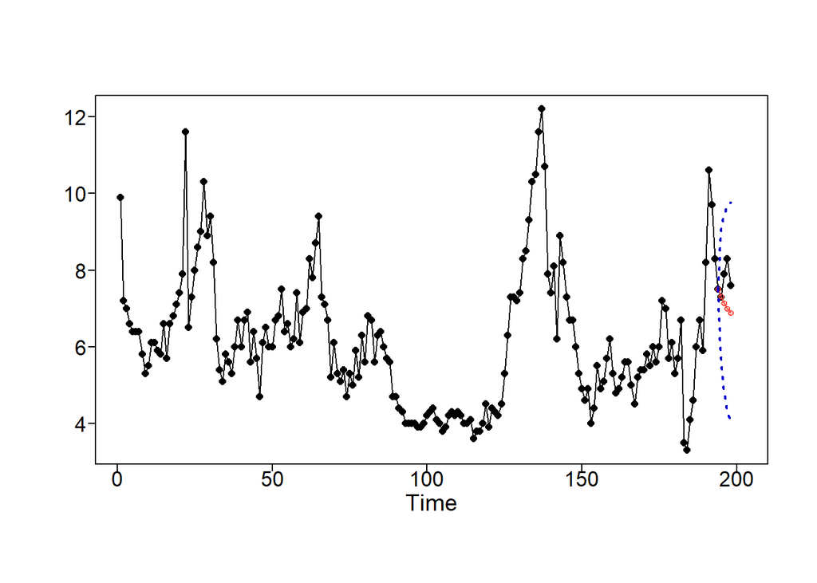

```r
ase = mean((x[(l-h.short+1):l]-f$f)^2)
ase # 0.6951032
```

```
## [1] 0.6951032
```

```r
f = fore.arima.wge(x,phi=est$phi,n.ahead=h.long,lastn=TRUE)
```

```
## y.arma 9.9 7.2 7 6.6 6.4 6.4 6.4 5.8 5.3 5.5 6.1 6.1 5.9 5.8 6.6 5.7 6.6 6.8 7.1 7.4 7.9 11.6 6.5 7.3 8 8.6 9 10.3 8.9 9.4 8.2 6.2 5.4 5.1 5.8 5.6 5.3 6 6.7 6 6.7 6.9 5.6 6.4 5.7 4.7 6.1 6.5 6 6 6.7 6.8 7.5 6.4 6.6 6 6.2 7.4 6.1 6.9 7 8.3 7.8 8.7 9.4 7.3 7.1 6.7 5.2 6.1 5.3 5.1 5.4 4.7 5.3 5 5.9 …
```

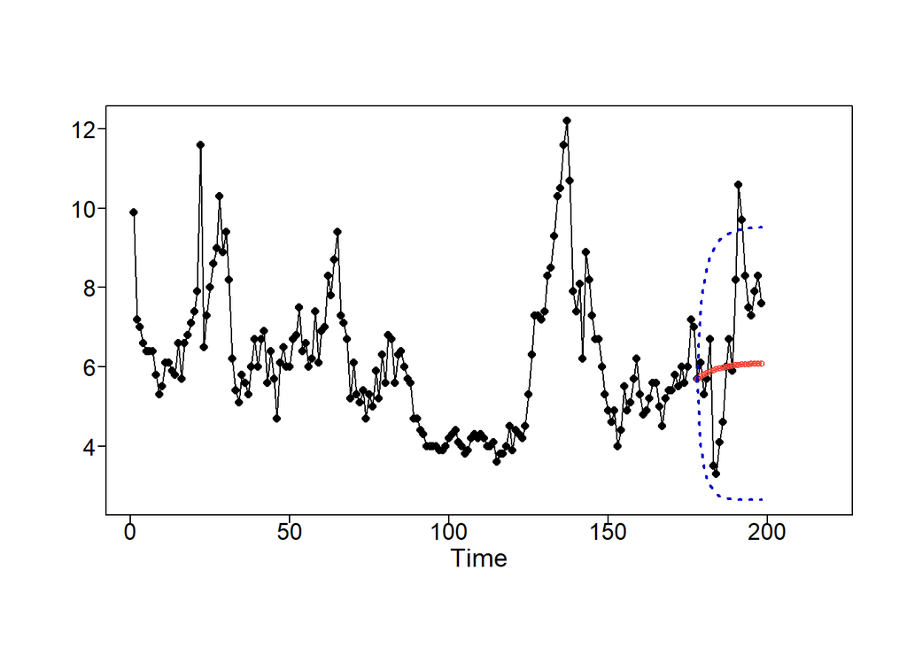

```r
ase = mean((x[(l-h.long+1):l]-f$f)^2)
ase # 3.865913
```

```
## [1] 3.865913
```

```r
est = est.arma.wge(x,p=1,q=1)
```

```
##
##
## Coefficients of AR polynomial:
## 0.8930
##
##                            AR Factor Table
## Factor                 Roots                Abs Recip    System Freq
## 1-0.8930B              1.1198               0.8930       0.0000
##
##
##
##
## Coefficients of MA polynomial:
## 0.1287
##
##                               MA FACTOR TABLE
## Factor                 Roots                Abs Recip    System Freq
## 1-0.1287B              7.7707               0.1287       0.0000
##
##
```

```r
f = fore.arima.wge(x,phi=est$phi,theta=est$theta,n.ahead=h.short,lastn=TRUE)
```

```
## y.arma 9.9 7.2 7 6.6 6.4 6.4 6.4 5.8 5.3 5.5 6.1 6.1 5.9 5.8 6.6 5.7 6.6 6.8 7.1 7.4 7.9 11.6 6.5 7.3 8 8.6 9 10.3 8.9 9.4 8.2 6.2 5.4 5.1 5.8 5.6 5.3 6 6.7 6 6.7 6.9 5.6 6.4 5.7 4.7 6.1 6.5 6 6 6.7 6.8 7.5 6.4 6.6 6 6.2 7.4 6.1 6.9 7 8.3 7.8 8.7 9.4 7.3 7.1 6.7 5.2 6.1 5.3 5.1 5.4 4.7 5.3 5 5.9 …
```

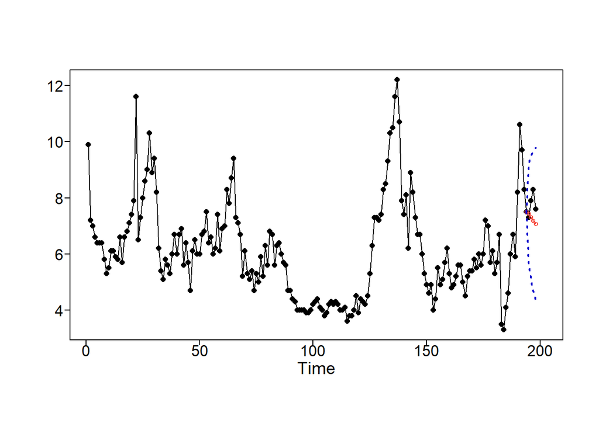

```r
ase = mean((x[(l-h.short+1):l]-f$f)^2)
ase # 0.4791473
```

```
## [1] 0.4791473
```

```r
f = fore.arima.wge(x,phi=est$phi,theta=est$theta,n.ahead=h.long,lastn=TRUE)
```

```
## y.arma 9.9 7.2 7 6.6 6.4 6.4 6.4 5.8 5.3 5.5 6.1 6.1 5.9 5.8 6.6 5.7 6.6 6.8 7.1 7.4 7.9 11.6 6.5 7.3 8 8.6 9 10.3 8.9 9.4 8.2 6.2 5.4 5.1 5.8 5.6 5.3 6 6.7 6 6.7 6.9 5.6 6.4 5.7 4.7 6.1 6.5 6 6 6.7 6.8 7.5 6.4 6.6 6 6.2 7.4 6.1 6.9 7 8.3 7.8 8.7 9.4 7.3 7.1 6.7 5.2 6.1 5.3 5.1 5.4 4.7 5.3 5 5.9 …
```

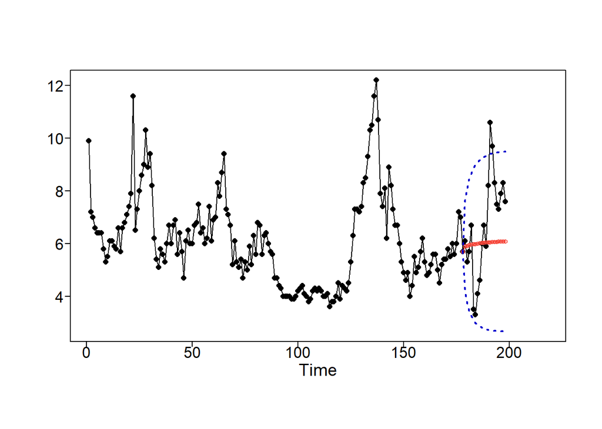

```r
ase = mean((x[(l-h.long+1):l]-f$f)^2)
ase # 3.901133
```

```
## [1] 3.901133
```

The short term ASE for the ARMA(1,1) is significantly better, but the long term ASE is a little worse. We will proceed with the ARMA(1,1) model.

```r
x = fed_housing_data$Supply_New_Houses
est = est.arma.wge(x,p=1,q=1)
```

```
##
##
## Coefficients of AR polynomial:
## 0.8930
##
##                            AR Factor Table
## Factor                 Roots                Abs Recip    System Freq
## 1-0.8930B              1.1198               0.8930       0.0000
##
##
##
##
## Coefficients of MA polynomial:
## 0.1287
##
##                               MA FACTOR TABLE
## Factor                 Roots                Abs Recip    System Freq
## 1-0.1287B              7.7707               0.1287       0.0000
##
##
```

```r
f = fore.arima.wge(x,phi=est$phi,theta=est$theta,n.ahead=h.short,lastn=TRUE)
```

```
## y.arma 9.9 7.2 7 6.6 6.4 6.4 6.4 5.8 5.3 5.5 6.1 6.1 5.9 5.8 6.6 5.7 6.6 6.8 7.1 7.4 7.9 11.6 6.5 7.3 8 8.6 9 10.3 8.9 9.4 8.2 6.2 5.4 5.1 5.8 5.6 5.3 6 6.7 6 6.7 6.9 5.6 6.4 5.7 4.7 6.1 6.5 6 6 6.7 6.8 7.5 6.4 6.6 6 6.2 7.4 6.1 6.9 7 8.3 7.8 8.7 9.4 7.3 7.1 6.7 5.2 6.1 5.3 5.1 5.4 4.7 5.3 5 5.9 …
```

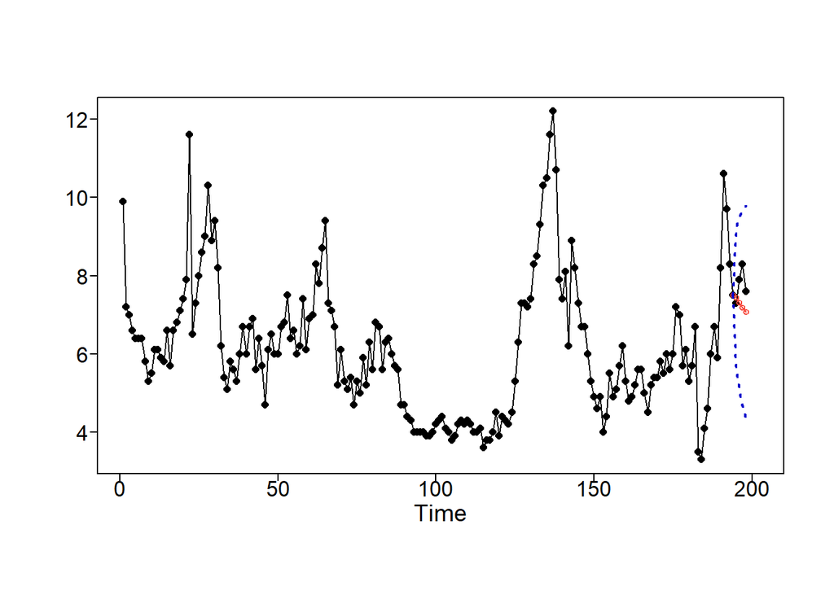

```r
snh.pred.short = f$f
f = fore.arima.wge(x,phi=est$phi,theta=est$theta,n.ahead=h.long,lastn=TRUE)
```

```
## y.arma 9.9 7.2 7 6.6 6.4 6.4 6.4 5.8 5.3 5.5 6.1 6.1 5.9 5.8 6.6 5.7 6.6 6.8 7.1 7.4 7.9 11.6 6.5 7.3 8 8.6 9 10.3 8.9 9.4 8.2 6.2 5.4 5.1 5.8 5.6 5.3 6 6.7 6 6.7 6.9 5.6 6.4 5.7 4.7 6.1 6.5 6 6 6.7 6.8 7.5 6.4 6.6 6 6.2 7.4 6.1 6.9 7 8.3 7.8 8.7 9.4 7.3 7.1 6.7 5.2 6.1 5.3 5.1 5.4 4.7 5.3 5 5.9 …
```

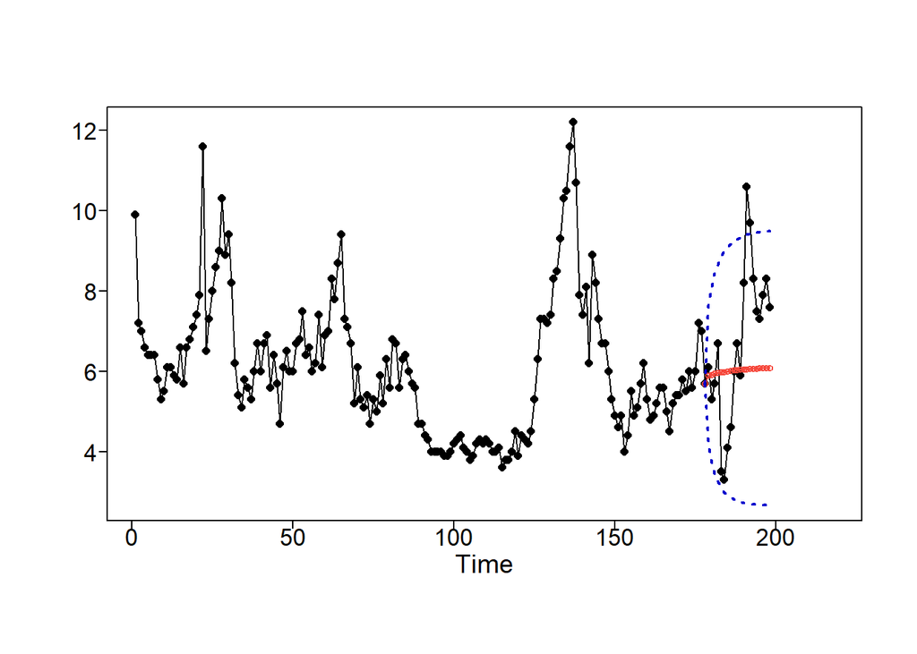

```r
snh.pred.long = f$f
fed_housing_data_short$Supply_New_Houses[(l-h.short+1):l] = snh.pred.short
fed_housing_data_long$Supply_New_Houses[(l-h.long+1):l] = snh.pred.long
```

## House price index

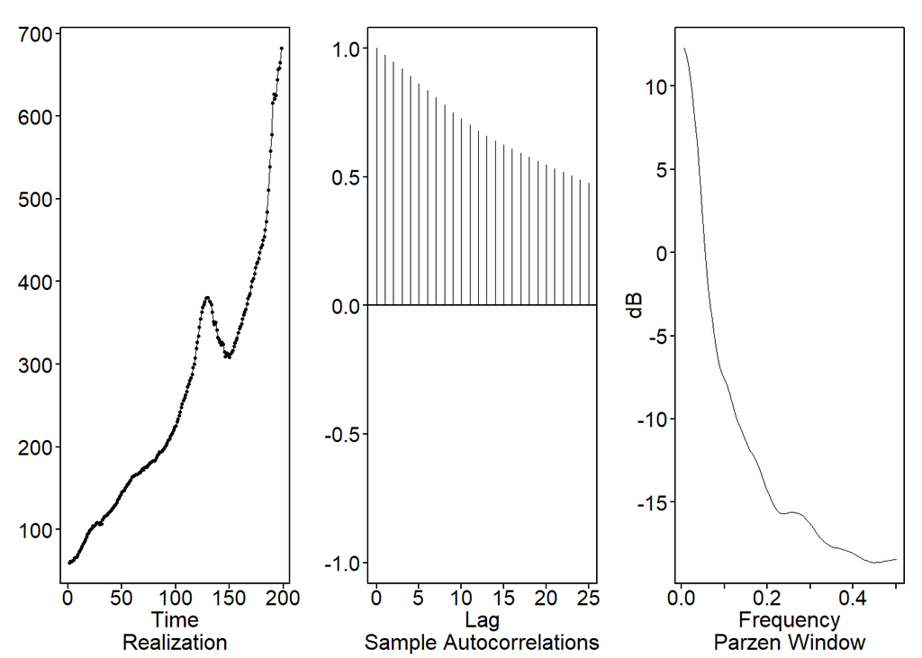

```
## $xbar
## [1] 260.0757
##
## $autplt
##  [1] 1.0000000 0.9729202 0.9462056 0.9191307 0.8909986 0.8628031 0.8357103
##  [8] 0.8082155 0.7793027 0.7505719 0.7251203 0.7011544 0.6785046 0.6582523
## [15] 0.6404179 0.6234247 0.6071393 0.5914399 0.5759915 0.5608527 0.5458586
## [22] 0.5311570 0.5169824 0.5031950 0.4892727 0.4755910
##
## $freq
##  [1] 0.005050505 0.010101010 0.015151515 0.020202020 0.025252525 0.030303030
##  [7] 0.035353535 0.040404040 0.045454545 0.050505051 0.055555556 0.060606061
## [13] 0.065656566 0.070707071 0.075757576 0.080808081 0.085858586 0.090909091
## [19] 0.095959596 0.101010101 0.106060606 0.111111111 0.116161616 0.121212121
## [25] 0.126262626 0.131313131 0.136363636 0.141414141 0.146464646 0.151515152
```

[output cut: 31 more lines]

```r
x = fed_housing_data$Housing_Price_Index
plotts.sample.wge(x)
```

```r
d = artrans.wge(x,1)
```

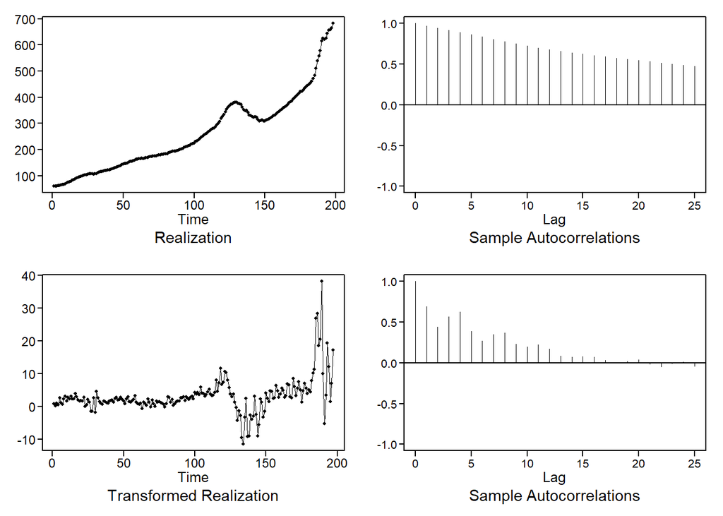

```r
d2 = artrans.wge(d,1)
```

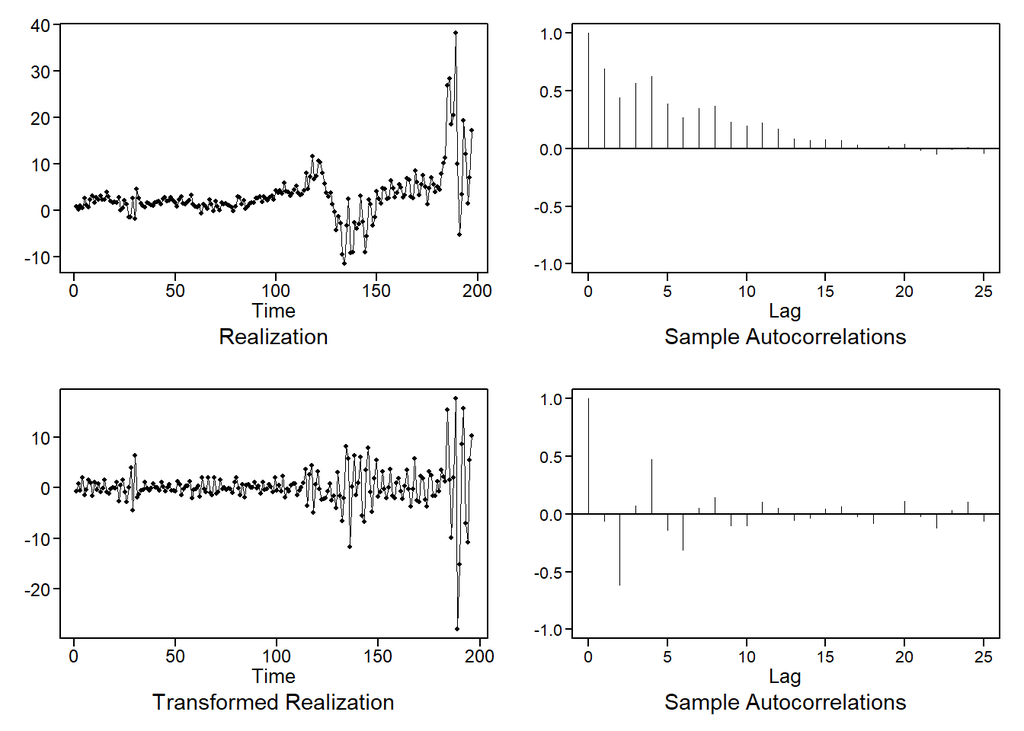

```r
dev.off()
```

```r
parzen.wge(d2)
```

[output not shown]

[output cut: 25 more lines]

```r
d3 = artrans.wge(d2,c(0,-1))
dev.off()
```

```r
acf(d3,lag.max=100)
```

However, unlike the other variables, it looked like a single difference wasn’t white noise. Even differencing out the (1-B)^2 still had a 0.25 frequency. Differencing out that frequency as well looked more like white noise. So we will look at a signal plus noise model and a (1-B)^2*(1+B^2) model.

```r
f = fore.sigplusnoise.wge(x,max.p=0,n.ahead=h.short,lastn=TRUE)
```

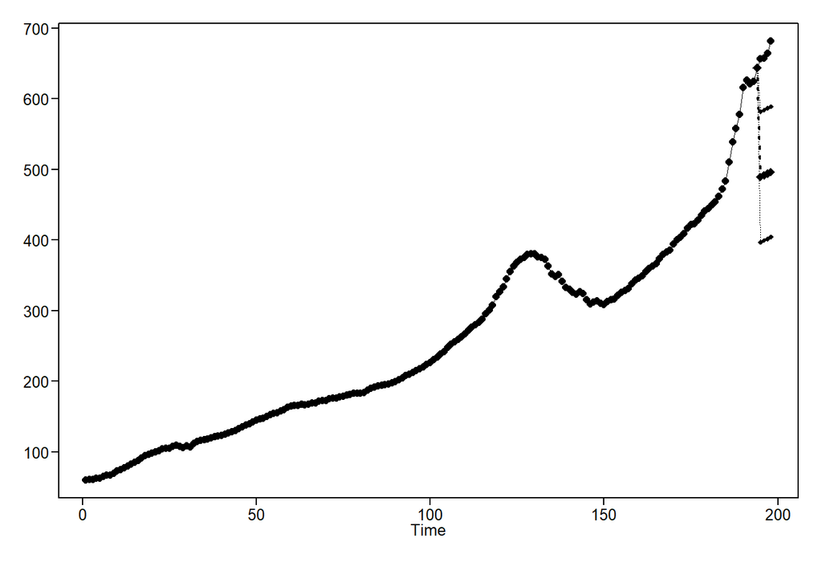

```r
aic5.ar.wge(f$resid,p=0:20) # p = 9
```

```
## ---------WORKING... PLEASE WAIT...
##
##
## Error in aic calculation at 1
## Error in aic calculation at 2
## Error in aic calculation at 3
## Error in aic calculation at 12
## Error in aic calculation at 14
## Error in aic calculation at 17
## Error in aic calculation at 18
## Error in aic calculation at 19
## Error in aic calculation at 20
## Five Smallest Values of  aic
## Method= mle
##     p        aic
##     9   2.299272
##     6   2.299300
##     7   2.305336
##    10   2.305733
##    13   2.311372
```

```r
f = fore.sigplusnoise.wge(x,max.p=9,n.ahead=h.short,lastn=TRUE)
```

```
##
##
## Coefficients of AR polynomial:
## 1.8014 -1.2205 0.8755 -0.2603 -0.5252 0.4232 -0.2115 0.2703 -0.1651
##
##                            AR Factor Table
## Factor                 Roots                Abs Recip    System Freq
## 1-1.9514B+0.9573B^2    1.0192+-0.0764i      0.9784       0.0119
## 1+0.0202B+0.8230B^2   -0.0123+-1.1022i      0.9072       0.2518
## 1+0.7906B             -1.2649               0.7906       0.5000
## 1-1.2751B+0.5746B^2    1.1097+-0.7136i      0.7580       0.0910
## 1+0.6143B+0.4614B^2   -0.6656+-1.3130i      0.6793       0.3247
##
##
```

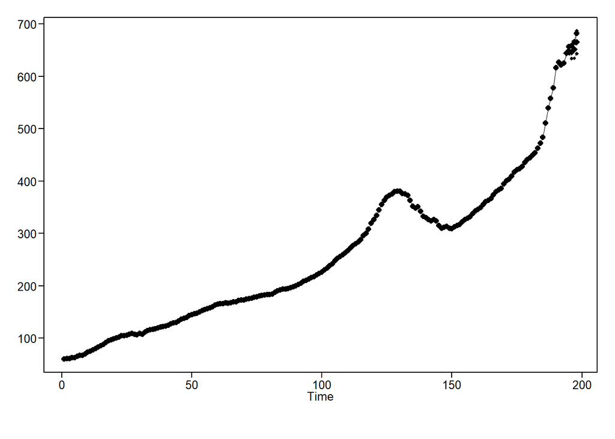

```r
ase = mean((x[(l-h.short+1):l]-f$f)^2)
ase # 161.2832
```

```
## [1] 161.2832
```

```r
f = fore.sigplusnoise.wge(x,max.p=9,n.ahead=h.long,lastn=TRUE)
```

```
##
##
## Coefficients of AR polynomial:
## 1.8014 -1.2205 0.8755 -0.2603 -0.5252 0.4232 -0.2115 0.2703 -0.1651
##
##                            AR Factor Table
## Factor                 Roots                Abs Recip    System Freq
## 1-1.9514B+0.9573B^2    1.0192+-0.0764i      0.9784       0.0119
## 1+0.0202B+0.8230B^2   -0.0123+-1.1022i      0.9072       0.2518
## 1+0.7906B             -1.2649               0.7906       0.5000
## 1-1.2751B+0.5746B^2    1.1097+-0.7136i      0.7580       0.0910
## 1+0.6143B+0.4614B^2   -0.6656+-1.3130i      0.6793       0.3247
##
##
```

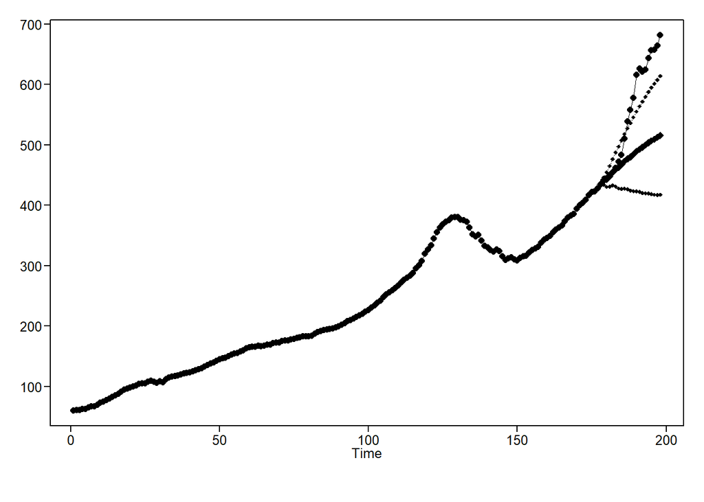

```r
ase = mean((x[(l-h.long+1):l]-f$f)^2)
ase # 10014.69
```

```
## [1] 10014.69
```

The short term ASE is 161 and the long term ASE is 10,014.

```r
aic5.wge(d3,p=0:8,q=0:6,type='aic') # 4/5 best
```

```
## ---------WORKING... PLEASE WAIT...
##
##
## Five Smallest Values of  aic
##     p    q        aic
##     4    5   2.318766
##     3    5   2.318801
##     5    5   2.331189
##     6    5   2.335669
##     2    5   2.343238
```

It looks like the model with p = 4 and q = 5 had the best AIC.

```r
est = est.arma.wge(d3,p=4,q=5)
```

```
##
##
## Coefficients of AR polynomial:
## -0.2653 0.1543 0.4275 0.2777
##
##                            AR Factor Table
## Factor                 Roots                Abs Recip    System Freq
## 1-0.8773B              1.1399               0.8773       0.0000
## 1+0.5373B+0.5229B^2   -0.5138+-1.2839i      0.7231       0.3106
## 1+0.6053B             -1.6520               0.6053       0.5000
##
##
##
##
## Coefficients of MA polynomial:
## -0.0912 -0.2272 0.4182 0.4609 0.4392
##
##                               MA FACTOR TABLE
## Factor                 Roots                Abs Recip    System Freq
## 1-1.0000B              1.0000               1.0000       0.0000
## 1-0.0322B+0.8167B^2    0.0197+-1.1064i      0.9037       0.2472
## 1+1.1234B+0.5378B^2   -1.0444+-0.8767i      0.7334       0.3889
##
##
```

```r
m = mult.wge(fac1=est$phi,fac2=c(0,-1))
factor.wge(m$model.coef) # looks good
```

```
##
##
## Coefficients of AR polynomial:
## -0.2653 -0.8457 0.1622 0.4320 0.4275 0.2777
##
##                            AR Factor Table
## Factor                 Roots                Abs Recip    System Freq
## 1+0.0000B+1.0000B^2    0.0000+-1.0000i      1.0000       0.2500
## 1-0.8773B              1.1399               0.8773       0.0000
## 1+0.5373B+0.5229B^2   -0.5138+-1.2839i      0.7231       0.3106
## 1+0.6053B             -1.6520               0.6053       0.5000
##
##
```

```r
f = fore.arima.wge(x,d=2,phi=m$model.coef,theta=est$theta,n.ahead=h.short,lastn=TRUE)
```

[output not shown]

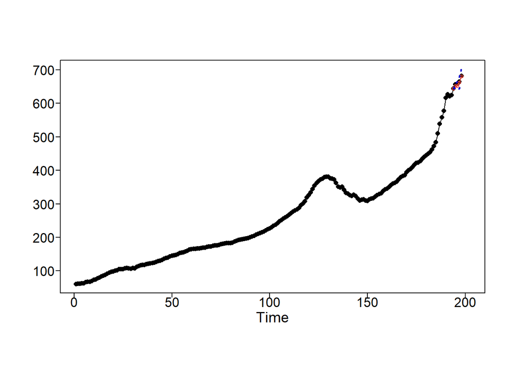

```r
ase = mean((x[(l-h.short+1):l]-f$f)^2)
ase # 16.01932
```

```
## [1] 16.01932
```

```r
f = fore.arima.wge(x,d=2,phi=m$model.coef,theta=est$theta,n.ahead=h.long,lastn=TRUE)
```

[output not shown]

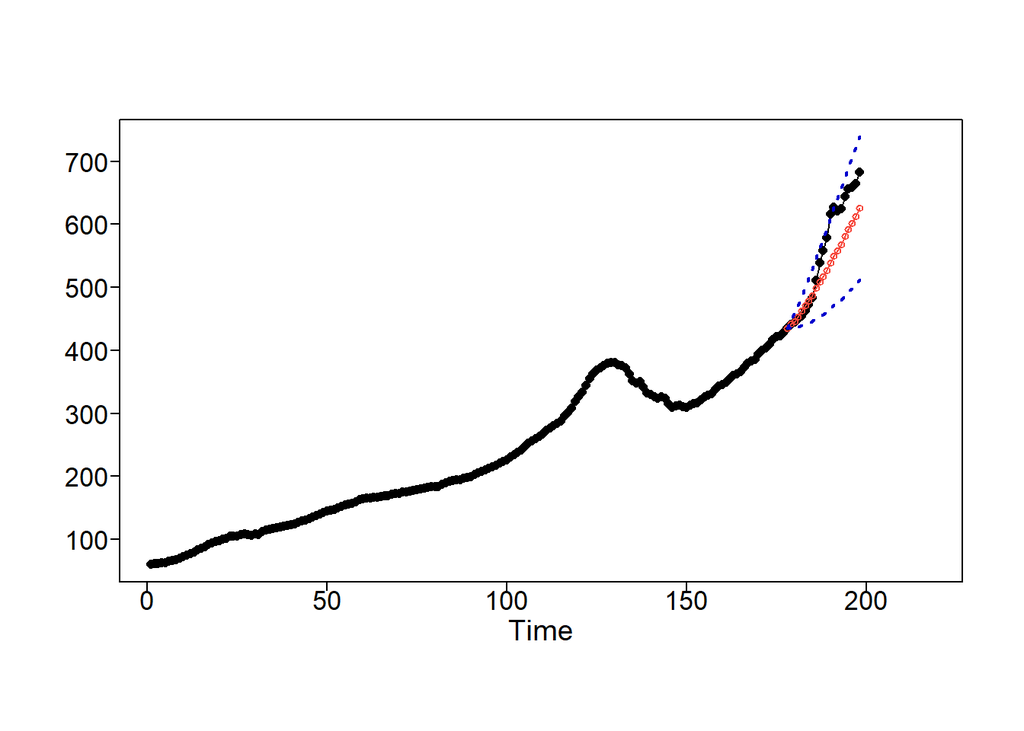

```r
ase = mean((x[(l-h.long+1):l]-f$f)^2)
ase # 2109.469
```

```
## [1] 2109.469
```

This model did significantly better with a short term ASE of 16 and a long term ASE of 2,109. Testing out some of the other values from aic5, found that p = 6 and q = 5 did even better.

```r
est = est.arma.wge(d3,p=6,q=5)
```

```
##
##
## Coefficients of AR polynomial:
## -0.8116 0.2231 0.5831 0.5250 0.1352 -0.2199
##
##                            AR Factor Table
## Factor                 Roots                Abs Recip    System Freq
## 1+1.7230B+0.8346B^2   -1.0323+-0.3642i      0.9136       0.4460
## 1-0.8558B              1.1685               0.8558       0.0000
## 1+0.4123B+0.6580B^2   -0.3132+-1.1923i      0.8112       0.2909
## 1-0.4679B              2.1373               0.4679       0.0000
##
##
##
##
## Coefficients of MA polynomial:
## -0.6419 -0.0609 0.3220 0.7473 0.6335
##
##                               MA FACTOR TABLE
## Factor                 Roots                Abs Recip    System Freq
## 1-1.0000B              1.0000               1.0000       0.0000
## 1+0.0687B+0.8449B^2   -0.0407+-1.0872i      0.9192       0.2560
## 1+1.5732B+0.7497B^2   -1.0492+-0.4827i      0.8659       0.4314
##
##
```

```r
m = mult.wge(fac1=est$phi,fac2=c(0,-1))
factor.wge(m$model.coef) # looks good
```

```
##
##
## Coefficients of AR polynomial:
## -0.8116 -0.7769 -0.2285 0.7481 0.7183 0.3051 0.1352 -0.2199
##
##                            AR Factor Table
## Factor                 Roots                Abs Recip    System Freq
## 1+0.0000B+1.0000B^2    0.0000+-1.0000i      1.0000       0.2500
## 1+1.7230B+0.8346B^2   -1.0323+-0.3642i      0.9136       0.4460
## 1-0.8558B              1.1685               0.8558       0.0000
## 1+0.4123B+0.6580B^2   -0.3132+-1.1923i      0.8112       0.2909
## 1-0.4679B              2.1373               0.4679       0.0000
##
##
```

```r
f = fore.arima.wge(x,d=2,phi=m$model.coef,theta=est$theta,n.ahead=h.short,lastn=TRUE)
```

[output not shown]

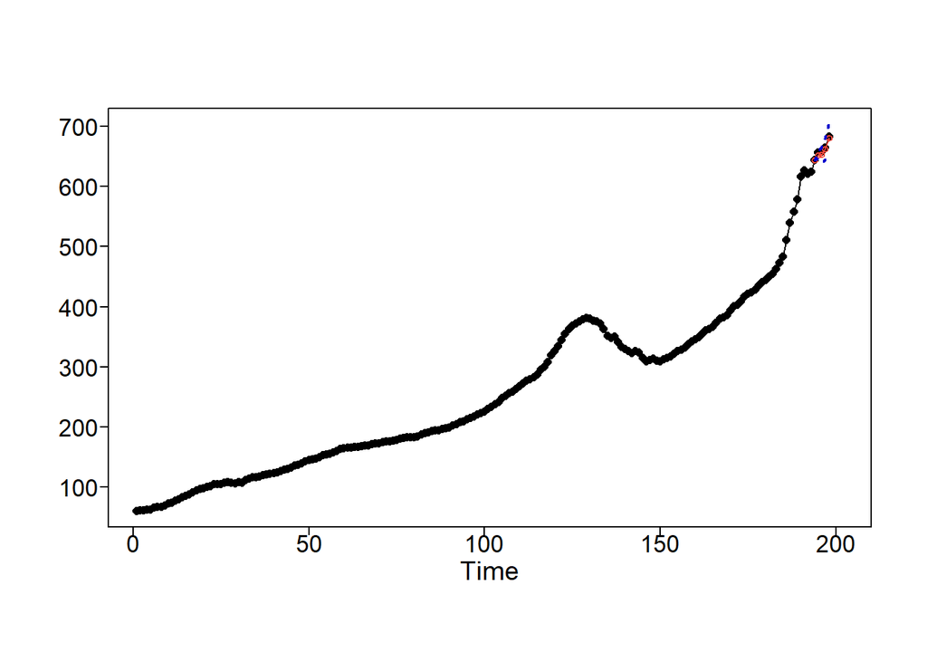

```r
ase = mean((x[(l-h.short+1):l]-f$f)^2)
ase # 14.86637
```

```
## [1] 14.86637
```

```r
f = fore.arima.wge(x,d=2,phi=m$model.coef,theta=est$theta,n.ahead=h.long,lastn=TRUE)
```

[output not shown]

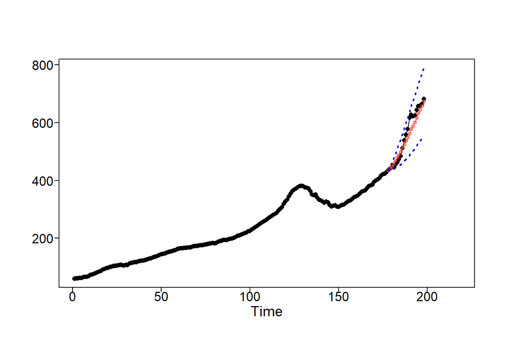

```r
ase = mean((x[(l-h.long+1):l]-f$f)^2)
ase # 558.2356
```

```
## [1] 558.2356
```

This model had a short term ASE of 15 and a long term ASE of 558. This is the model we will use to get the forecasts.

```r
x = fed_housing_data$Housing_Price_Index
d = artrans.wge(x,1)
```

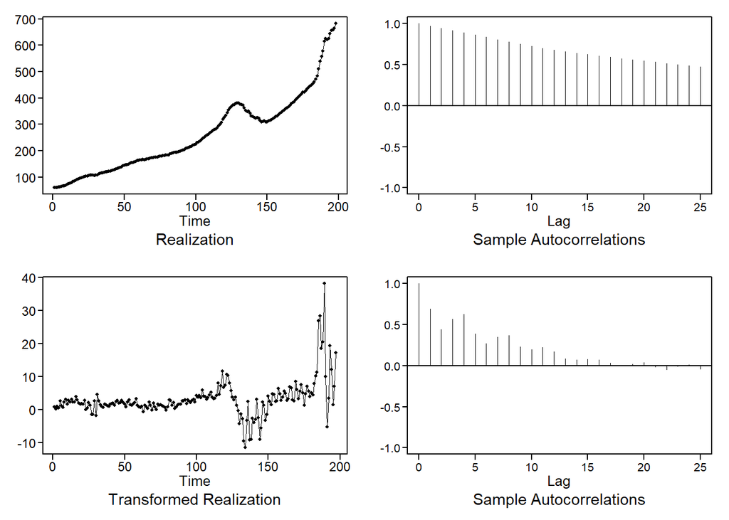

```r
d2 = artrans.wge(d,1)
```

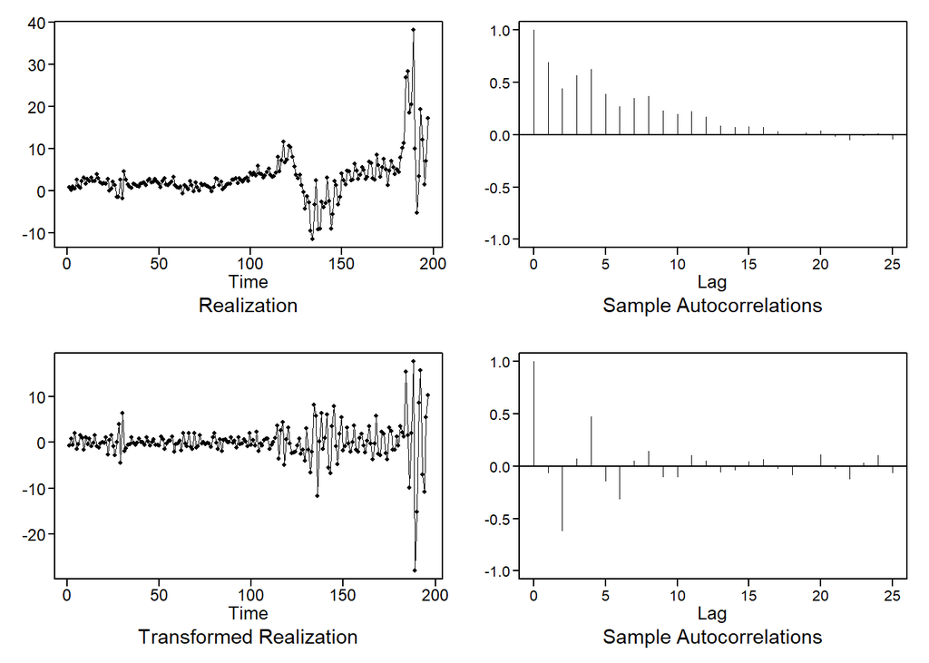

```r
d3 = artrans.wge(d2,c(0,-1))
```

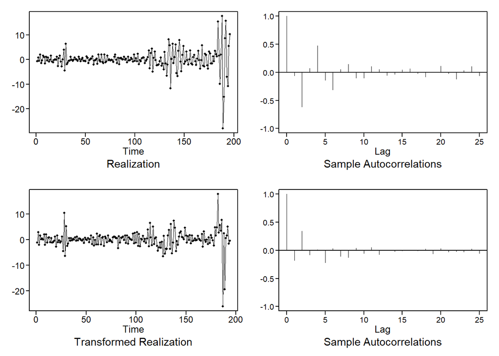

```r
est = est.arma.wge(d3,p=6,q=5)
```

```
##
##
## Coefficients of AR polynomial:
## -0.8116 0.2231 0.5831 0.5250 0.1352 -0.2199
##
##                            AR Factor Table
## Factor                 Roots                Abs Recip    System Freq
## 1+1.7230B+0.8346B^2   -1.0323+-0.3642i      0.9136       0.4460
## 1-0.8558B              1.1685               0.8558       0.0000
## 1+0.4123B+0.6580B^2   -0.3132+-1.1923i      0.8112       0.2909
## 1-0.4679B              2.1373               0.4679       0.0000
##
##
##
##
## Coefficients of MA polynomial:
## -0.6419 -0.0609 0.3220 0.7473 0.6335
##
##                               MA FACTOR TABLE
## Factor                 Roots                Abs Recip    System Freq
## 1-1.0000B              1.0000               1.0000       0.0000
## 1+0.0687B+0.8449B^2   -0.0407+-1.0872i      0.9192       0.2560
## 1+1.5732B+0.7497B^2   -1.0492+-0.4827i      0.8659       0.4314
##
##
```

```r
m = mult.wge(fac1=est$phi,fac2=c(0,-1))
f = fore.arima.wge(x,d=2,phi=m$model.coef,theta=est$theta,n.ahead=h.short,lastn=TRUE)
```

[output not shown]

```r
hpi.pred.short = f$f
f = fore.arima.wge(x,d=2,phi=m$model.coef,theta=est$theta,n.ahead=h.long,lastn=TRUE)
```

[output not shown]

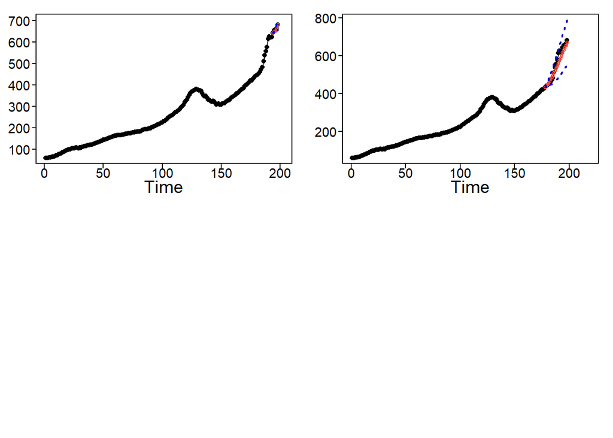

```r
hpi.pred.long = f$f
fed_housing_data_short$Housing_Price_Index[(l-h.short+1):l] = hpi.pred.short
fed_housing_data_long$Housing_Price_Index[(l-h.long+1):l] = hpi.pred.long
```

# Multi-variate Models

We will try out an MLR model with lag and a VAR model that predicts all variables at the same time. The exogenous predictions we made previously will be used for the MLR Model.

## MLR Model

We will first start by looking at the lag plots for the four exogenous variables.

```r
x = fed_housing_data
l = ccf(x$Median_Sales_Price,x$Ownership_Rate,lag.max=80)
```

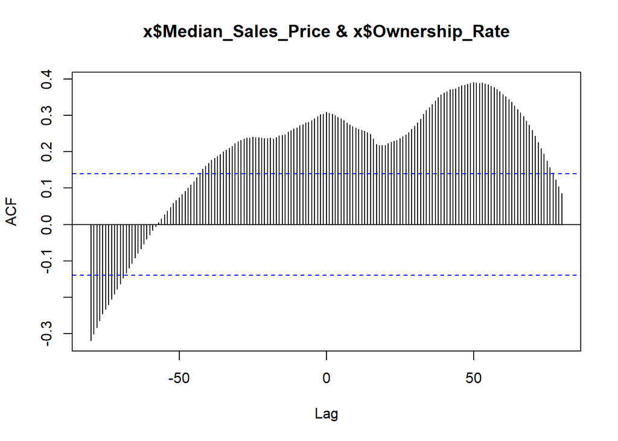

```r
which.max(l$acf)
```

```
## [1] 131
```

```r
l$acf[20] # 0.3090685
```

```
## [1] -0.03980345
```

```r
l$lag[20] # 0
```

```
## [1] -61
```

```r
l = ccf(x$Median_Sales_Price,x$Housing_Units_Completed,lag.max=80)
```

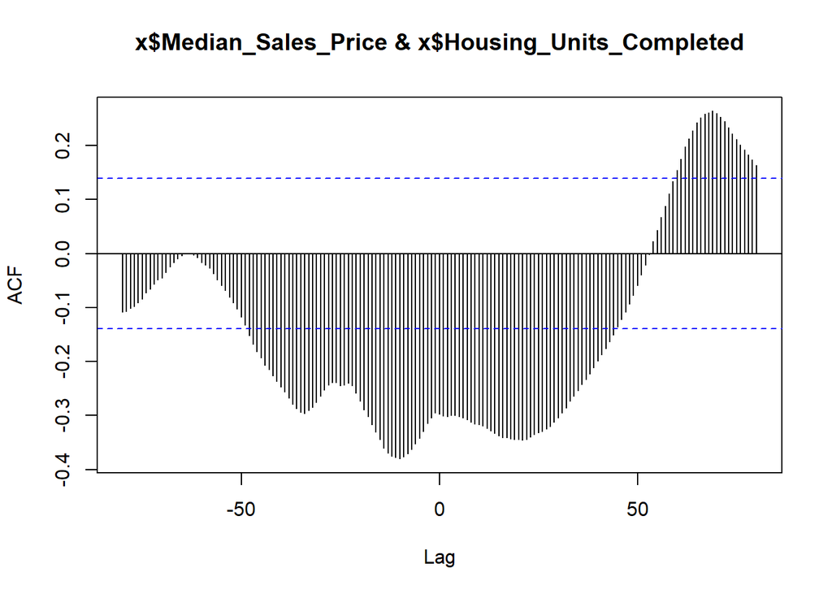

```r
which.max(l$acf)
```

```
## [1] 150
```

```r
l$acf[150] # 0.263895
```

```
## [1] 0.263895
```

```r
l$lag[150] # 69, 21 seemed alright
```

```
## [1] 69
```

```r
l = ccf(x$Median_Sales_Price,x$Supply_New_Houses,lag.max=60)
```

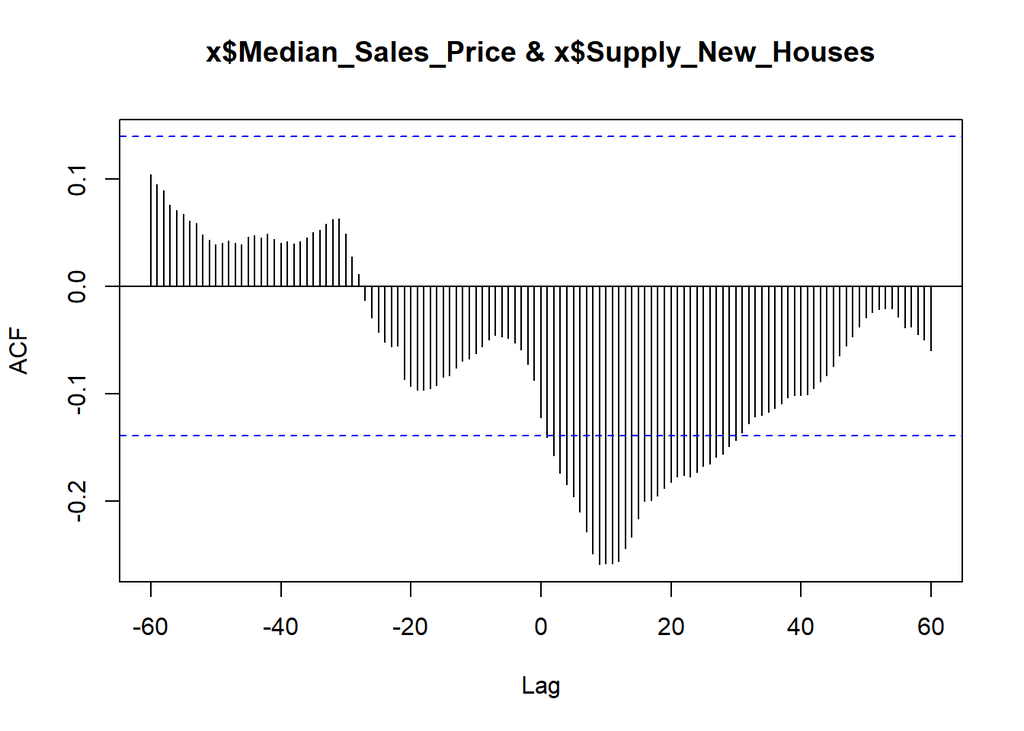

```r
which.min(l$acf)
```

```
## [1] 70
```

```r
l$acf[70] # -0.2592145
```

```
## [1] -0.2592145
```

```r
l$lag[70] # 9
```

```
## [1] 9
```

```r
l = ccf(x$Median_Sales_Price,x$Housing_Price_Index,lag.max=60)
```

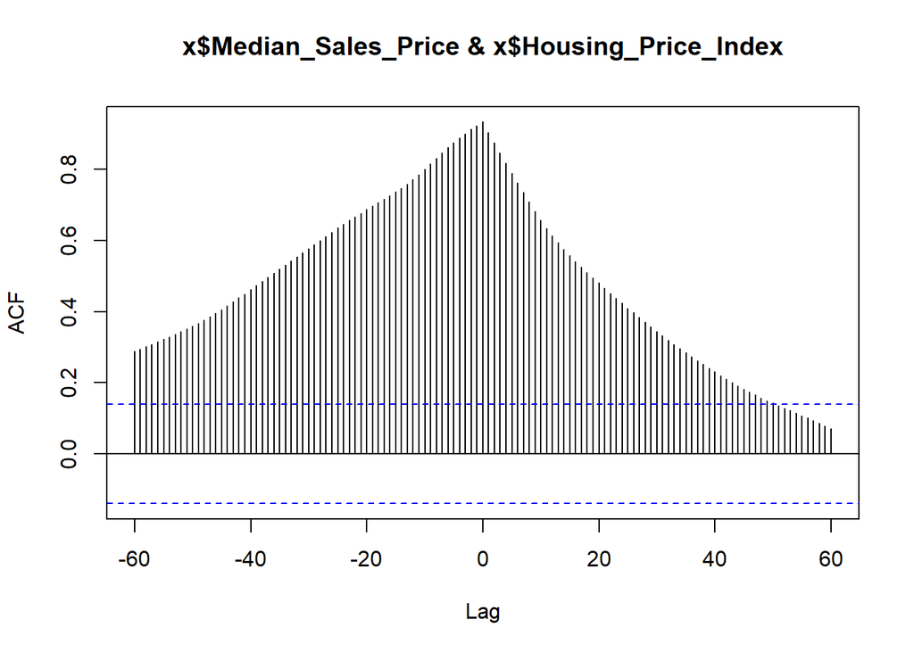

```r
which.max(l$acf)
```

```
## [1] 61
```

```r
l$acf[61] # 0.933195
```

```
## [1] 0.933195
```

```r
l$lag[61] # 0
```

```
## [1] 0
```

What does a model with these 4 lagged variables look like.

```r
x.short = fed_housing_data_short
x.long = fed_housing_data_long
x$Year_Quarter = c()
x.short$Year_Quarter = c()
x.long$Year_Quarter = c()
l = length(x$Median_Sales_Price)
t=1:l
t.train.short= 1:(l-h.short)
t.test.short=(l-h.short+1):l
t.train.long= 1:(l-h.long)
t.test.long=(l-h.long+1):l
x$Housing_Units_Completed_l21 = dplyr::lag(x$Housing_Units_Completed,21)
x$Supply_New_Houses_l9 = dplyr::lag(x$Supply_New_Houses,9)
x.short$Housing_Units_Completed_l21 = dplyr::lag(x.short$Housing_Units_Completed,21)
x.short$Supply_New_Houses_l9 = dplyr::lag(x.short$Supply_New_Houses,9)
x.long$Housing_Units_Completed_l21 = dplyr::lag(x.long$Housing_Units_Completed,21)
x.long$Supply_New_Houses_l9 = dplyr::lag(x.long$Supply_New_Houses,9)
ksfit = lm(x$Median_Sales_Price~x$Ownership_Rate+x$Housing_Units_Completed_l21+x$Supply_New_Houses_l9+x$Housing_Price_Index+t)
summary(ksfit)
```

```
##
## Call:
## lm(formula = x$Median_Sales_Price ~ x$Ownership_Rate + x$Housing_Units_Completed_l21 +
##     x$Supply_New_Houses_l9 + x$Housing_Price_Index + t)
##
## Residuals:
##       Min        1Q    Median        3Q       Max
## -0.161704 -0.039905  0.000082  0.037073  0.169569
##
## Coefficients:
##                                 Estimate Std. Error t value Pr(>|t|)
## (Intercept)                    1.121e+01  2.627e-01  42.655  < 2e-16 ***
## x$Ownership_Rate              -2.029e-03  4.165e-03  -0.487  0.62676
## x$Housing_Units_Completed_l21  5.980e-05  2.174e-05   2.751  0.00658 **
## x$Supply_New_Houses_l9        -2.926e-02  3.955e-03  -7.400 5.88e-12 ***
## x$Housing_Price_Index          2.695e-04  1.058e-04   2.548  0.01172 *
## t                              9.371e-03  2.996e-04  31.282  < 2e-16 ***
## ---
## Signif. codes:  0 '***' 0.001 '**' 0.01 '*' 0.05 '.' 0.1 ' ' 1
##
## Residual standard error: 0.06558 on 171 degrees of freedom
##   (21 observations deleted due to missingness)
## Multiple R-squared:  0.9847, Adjusted R-squared:  0.9842
## F-statistic:  2195 on 5 and 171 DF,  p-value: < 2.2e-16
```

```r
AIC(ksfit) # -454.2937
```

```
## [1] -454.2937
```

The Ownership rate variable didn’t have a very high p value, so it wasn’t significant in the model. Let’s see what happens when it is removed.

```r
ksfit = lm(x$Median_Sales_Price~x$Housing_Units_Completed_l21+x$Supply_New_Houses_l9+x$Housing_Price_Index+t)
summary(ksfit)
```

```
##
## Call:
## lm(formula = x$Median_Sales_Price ~ x$Housing_Units_Completed_l21 +
##     x$Supply_New_Houses_l9 + x$Housing_Price_Index + t)
##
## Residuals:
##       Min        1Q    Median        3Q       Max
## -0.162411 -0.041527 -0.001268  0.037562  0.172413
##
## Coefficients:
##                                 Estimate Std. Error t value Pr(>|t|)
## (Intercept)                    1.108e+01  3.039e-02 364.541  < 2e-16 ***
## x$Housing_Units_Completed_l21  5.310e-05  1.679e-05   3.163  0.00185 **
## x$Supply_New_Houses_l9        -2.821e-02  3.303e-03  -8.541 6.84e-15 ***
## x$Housing_Price_Index          2.695e-04  1.055e-04   2.554  0.01151 *
## t                              9.341e-03  2.925e-04  31.935  < 2e-16 ***
## ---
## Signif. codes:  0 '***' 0.001 '**' 0.01 '*' 0.05 '.' 0.1 ' ' 1
##
## Residual standard error: 0.06543 on 172 degrees of freedom
##   (21 observations deleted due to missingness)
## Multiple R-squared:  0.9846, Adjusted R-squared:  0.9843
## F-statistic:  2756 on 4 and 172 DF,  p-value: < 2.2e-16
```

```r
AIC(ksfit) # -456.0482
```

```
## [1] -456.0482
```

In this model, all the variables are significant. The AIC value is slightly lower as well. We will now determine how to model the residuals using an ARMA model.

```r
aic5.wge(ksfit$residuals,p=0:4,q=0:2,type='aic') # best 2/0
```

```
## ---------WORKING... PLEASE WAIT...
##
##
## Five Smallest Values of  aic
##     p    q        aic
##     2    0  -6.610677
##     1    1  -6.608485
##     3    0  -6.599501
##     2    1  -6.599466
##     1    2  -6.595973
```

The model with the best AIC is an AR(2).

```r
fit=arima(x.short$Median_Sales_Price[t.train.short],order=c(2,0,0),xreg=cbind(t.train.short,x.short$Housing_Units_Completed_l21[t.train.short],x.short$Supply_New_Houses_l9[t.train.short],x.short$Housing_Price_Index[t.train.short]))
preds = predict(fit,newxreg = data.frame(t=t.test.short,Housing_Units_Completed_l21=x.short$Housing_Units_Completed_l21[t.test.short],Supply_New_Houses_l9=x.short$Supply_New_Houses_l9[t.test.short],Housing_Price_Index=x.short$Housing_Price_Index[t.test.short]))
ase = mean((fed_housing_data_NL$Median_Sales_Price[t.test.short]-exp(preds$pred))^2)/1e6
ase # 588.675
```

```
## [1] 588.675
```

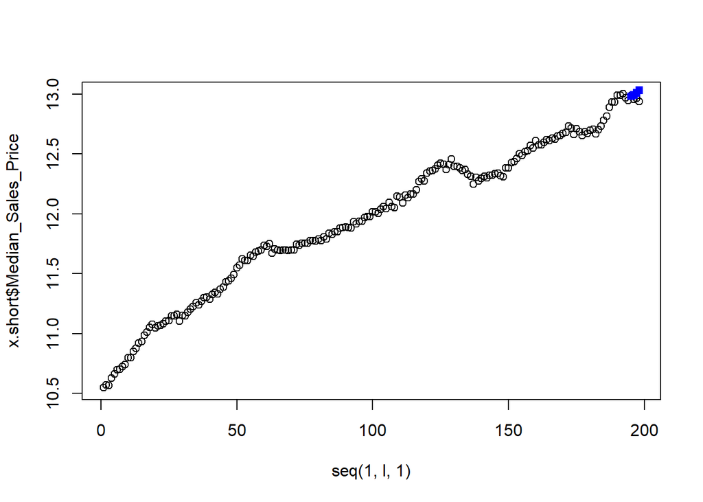

```r
plot(seq(1,l,1),x.short$Median_Sales_Price,type="b")
points(seq((l-h.short+1),l,1),preds$pred,type="b",pch=15,col="blue")
```

```r
fit=arima(x.long$Median_Sales_Price[t.train.long],order=c(2,0,0),xreg=cbind(t.train.long,x$Housing_Units_Completed_l21[t.train.long],x$Supply_New_Houses_l9[t.train.long],x$Housing_Price_Index[t.train.long]))
preds = predict(fit,newxreg = data.frame(t=t.test.short,Housing_Units_Completed_l21=x.long$Housing_Units_Completed_l21[t.test.long],Supply_New_Houses_l9=x.long$Supply_New_Houses_l9[t.test.long],Housing_Price_Index=x.long$Housing_Price_Index[t.test.long]))
ase = mean((fed_housing_data_NL$Median_Sales_Price[t.test.long]-exp(preds$pred))^2)/1e6
ase # 1431.873
```

```
## [1] 1431.873
```

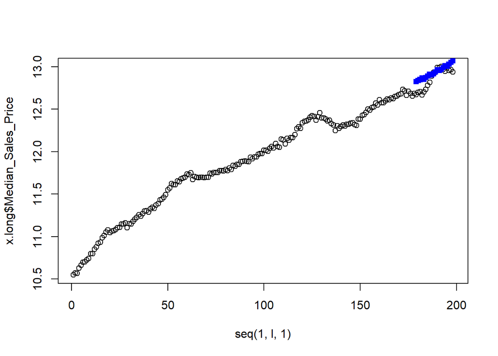

```r
plot(seq(1,l,1),x.long$Median_Sales_Price,type="b")
points(seq((l-h.long+1),l,1),preds$pred,type="b",pch=15,col="blue")
```

The short term ASE is 589 M and the long term ASE is 1.4 B.

## VAR Model

```r
x = fed_housing_data
x$Year_Quarter = c()
VARselect(x,lag.max=16,type="both",season=NULL,exogen=NULL) # lag = 4
```

```
## $selection
## AIC(n)  HQ(n)  SC(n) FPE(n)
##      4      2      1      4
##
## $criteria
##                1        2        3        4        5        6        7        8
## AIC(n)  2.330754 1.933777 1.831970 1.690855 1.754028 1.829078 1.939386 1.901505
## HQ(n)   2.580534 2.361972 2.438579 2.475879 2.717466 2.970931 3.259654 3.400187
## SC(n)   2.946909 2.990043 3.328346 3.627343 4.130626 4.645787 5.196206 5.598435
## FPE(n) 10.287646 6.922207 6.263258 5.456431 5.841904 6.344193 7.157132 6.985458
##               9       10       11       12       13       14       15        16
## AIC(n) 1.737782 1.757358 1.775183 1.828460 1.877812 1.886325 1.936906  1.981409
## HQ(n)  3.414879 3.612869 3.809109 4.040800 4.268567 4.455494 4.684489  4.907407
## SC(n)  5.874824 6.334511 6.792446 7.285834 7.775297 8.223921 8.714612  9.199226
## FPE(n) 6.035151 6.291181 6.580194 7.172464 7.838893 8.285860 9.211707 10.275979
```

The model with lag = 4 was chosen.

```r
fit = VAR(x,p=4,type='both')
summary(fit) # trend and const were significant, but only lag up to 2 for variable of interest, huc not very predictive
```

```
##
## VAR Estimation Results:
## =========================
## Endogenous variables: Ownership_Rate, Housing_Units_Completed, Supply_New_Houses, Housing_Price_Index, Median_Sales_Price
## Deterministic variables: both
## Sample size: 194
## Log Likelihood: -1409.069
## Roots of the characteristic polynomial:
## 1.019 0.9661 0.944 0.944 0.8338 0.8338 0.827 0.827 0.6592 0.6592 0.5734 0.5734 0.5261 0.5261 0.4336 0.4336 0.3419 0.3419 0.3146 0.09555
## Call:
## VAR(y = x, p = 4, type = "both")
##
##
## Estimation results for equation Ownership_Rate:
## ===============================================
## Ownership_Rate = Ownership_Rate.l1 + Housing_Units_Completed.l1 + Supply_New_Houses.l1 + Housing_Price_Index.l1 + Median_Sales_Price.l1 + Ownership_Rate.l2 + Housing_Units_Completed.l2 + Supply_New_Houses.l2 + Housing_Price_Index.l2 + Median_Sales_Price.l2 + Ownership_Rate.l3 + Housing_Units_Comp…
##
##                              Estimate Std. Error t value Pr(>|t|)
## Ownership_Rate.l1           0.8802438  0.0772448  11.396   <2e-16 ***
## Housing_Units_Completed.l1  0.0003522  0.0003466   1.016   0.3110
## Supply_New_Houses.l1        0.0178765  0.0320110   0.558   0.5773
## Housing_Price_Index.l1      0.0006370  0.0080791   0.079   0.9372
## Median_Sales_Price.l1      -1.2365449  1.1566036  -1.069   0.2865
## Ownership_Rate.l2          -0.1675348  0.1006641  -1.664   0.0979 .
## Housing_Units_Completed.l2  0.0001776  0.0004052   0.438   0.6617
## Supply_New_Houses.l2       -0.0620023  0.0390373  -1.588   0.1141
## Housing_Price_Index.l2      0.0013218  0.0153120   0.086   0.9313
## Median_Sales_Price.l2       0.7609832  1.2429600   0.612   0.5412
## Ownership_Rate.l3           0.2373131  0.0992393   2.391   0.0179 *
## Housing_Units_Completed.l3 -0.0002194  0.0003990  -0.550   0.5831
## Supply_New_Houses.l3        0.0633595  0.0399637   1.585   0.1147
## Housing_Price_Index.l3     -0.0003650  0.0158064  -0.023   0.9816
## Median_Sales_Price.l3       0.6246737  1.2399144   0.504   0.6150
## Ownership_Rate.l4           0.0110775  0.0763513   0.145   0.8848
## Housing_Units_Completed.l4  0.0001236  0.0003175   0.389   0.6976
## Supply_New_Houses.l4       -0.0003583  0.0358984  -0.010   0.9920
## Housing_Price_Index.l4     -0.0034601  0.0096862  -0.357   0.7214
## Median_Sales_Price.l4      -0.4423237  1.0989918  -0.402   0.6878
## const                       4.9666621  3.7849625   1.312   0.1912
## trend                       0.0084872  0.0054763   1.550   0.1230
```

[output cut: 178 more lines]

```
## Supply_New_Houses              0.02118               -0.141898
## Housing_Price_Index           -0.11443               -0.025044
## Median_Sales_Price            -0.15427                0.006775
##                         Supply_New_Houses Housing_Price_Index
## Ownership_Rate                    0.02118            -0.11443
## Housing_Units_Completed          -0.14190            -0.02504
## Supply_New_Houses                 1.00000            -0.17350
## Housing_Price_Index              -0.17350             1.00000
## Median_Sales_Price               -0.05085             0.04649
##                         Median_Sales_Price
## Ownership_Rate                   -0.154270
## Housing_Units_Completed           0.006775
## Supply_New_Houses                -0.050846
## Housing_Price_Index               0.046491
## Median_Sales_Price                1.000000
```

```r
preds=predict(fit,n.ahead=h.short)
ase = mean((fed_housing_data_NL$Median_Sales_Price[(l-h.short+1):l]-exp(preds$fcst$Median_Sales_Price[,1]))^2)/1e6
ase # 46.3595
```

```
## [1] 46.3595
```

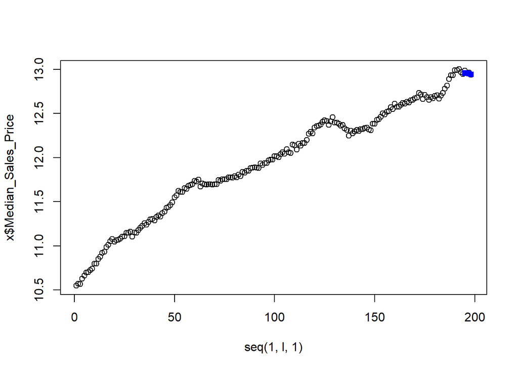

```r
plot(seq(1,l,1),x$Median_Sales_Price,type="b")
points(seq(l-h.short+1,l,1),preds$fcst$Median_Sales_Price[1:h.short,1],type="b",pch=15,col="blue")
```

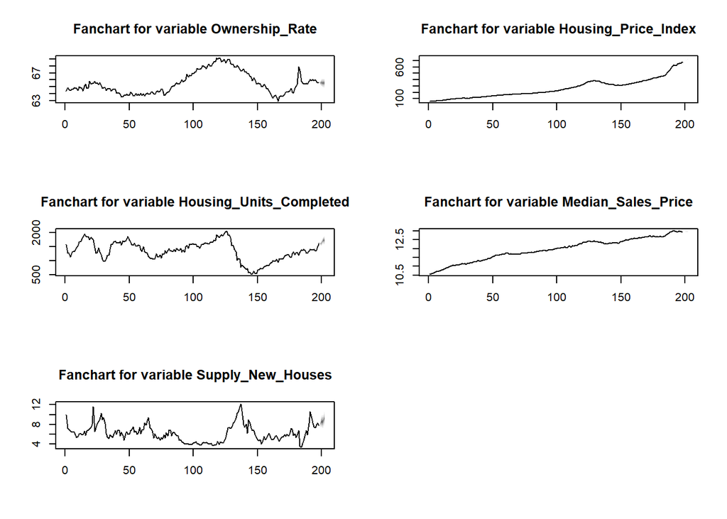

```r
fanchart(preds)
```

```r
preds=predict(fit,n.ahead=h.long)
ase = mean((fed_housing_data_NL$Median_Sales_Price[(l-h.long+1):l]-exp(preds$fcst$Median_Sales_Price[,1]))^2)/1e6
ase # 3499.949
```

```
## [1] 3499.949
```

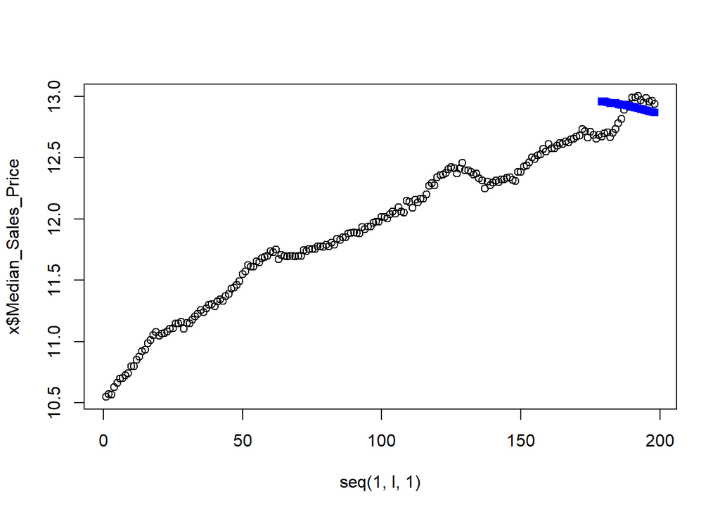

```r
plot(seq(1,l,1),x$Median_Sales_Price,type="b")
points(seq(l-h.long+1,l,1),preds$fcst$Median_Sales_Price[1:h.long,1],type="b",pch=15,col="blue")
```

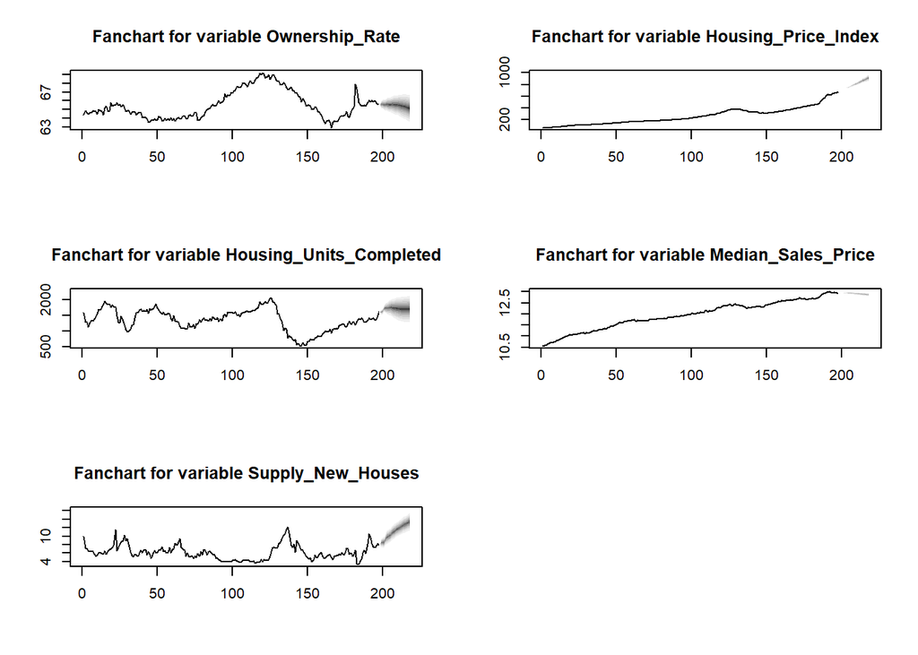

```r
fanchart(preds)
```

The VAR model has a very small short term ASE of 46.4 M. This is even smaller than the signal plus noise model. However, its long term ASE is larger than the MLR model.

# Neural Networks

We investigated 3 Neural Nets for predictions: Multilayer Perceptron (MLP), Long Short-Term Memory(LSTM), and Temporal Fusion Transformer (TFT).

## LSTM

LSTMs (Long Short-Term Memory) are a type of Recurrent Neural Network (RNN) that have shown success with Time Series data.

The LSTM was created in Python. The code is below.

```python
import torch
import torch.nn as nn
import pandas as pd
from torch.utils.data import Dataset, DataLoader
from sklearn.preprocessing import MinMaxScaler
import numpy as np
import random

class TimeSeriesDataset(Dataset):
    def __init__(self, data, sequence_length):
        self.data = torch.FloatTensor(data)
        self.sequence_length = sequence_length

    def __len__(self):
        return len(self.data) - self.sequence_length

    def __getitem__(self, idx):
        return (
            self.data[idx:idx+self.sequence_length],
            self.data[idx+self.sequence_length]
        )

class LSTM(nn.Module):
    def __init__(self, input_size, hidden_size, num_layers):
        super(LSTM, self).__init__()
        self.hidden_size = hidden_size
        self.num_layers = num_layers

        self.lstm = nn.LSTM(
            input_size=input_size,
            hidden_size=hidden_size,
            num_layers=num_layers,
            batch_first=True
        )

        self.fc = nn.Linear(hidden_size, 1)

    def forward(self, x):
        # Initialize hidden state with zeros
        h0 = torch.zeros(self.num_layers, x.size(0), self.hidden_size).to(x.device)
        # Initialize cell state
        c0 = torch.zeros(self.num_layers, x.size(0), self.hidden_size).to(x.device)

        # Forward propagate LSTM
        out, _ = self.lstm(x, (h0, c0))

        # Decode the hidden state of the last time step
        out = self.fc(out[:, -1, :])
        return out

def train_model(model, train_loader, criterion, optimizer, num_epochs):
    model.train()
    for epoch in range(num_epochs):
        total_loss = 0
        for batch_x, batch_y in train_loader:
            batch_x = batch_x.unsqueeze(-1) # Ensure batch_x is 3-D: (batch_size, sequence_length, input_size)
            optimizer.zero_grad()
            outputs = model(batch_x)
            loss = criterion(outputs, batch_y.unsqueeze(1))
            loss.backward()
            optimizer.step()
            total_loss += loss.item()

        print(f'Epoch [{epoch+1}/{num_epochs}], Loss: {total_loss/len(train_loader):.4f}')

# After evaluation
def save_results_to_csv(predictions, actuals, ase, horizon_type="short"):
    results_df = pd.DataFrame({
        'Prediction': predictions,
        'Actual': actuals,
        'Error': [pred - act for pred, act in zip(predictions, actuals)]
    })

    # Add summary statistics
    summary_df = pd.DataFrame({
        'Metric': ['ASE'],
        'Value': [ase]
    })

    # Save to CSV files
    results_df.to_csv(f'predictions_{horizon_type}_term.csv', index=True)
    summary_df.to_csv(f'metrics_{horizon_type}_term.csv', index=False)

# Set seeds for reproducibility
torch.manual_seed(42)
np.random.seed(42)
random.seed(42)
if torch.cuda.is_available():
    torch.cuda.manual_seed(42)
    torch.backends.cudnn.deterministic = True
    torch.backends.cudnn.benchmark = False

# Load and preprocess your data
df = pd.read_csv('https://raw.githubusercontent.com/aabromowitz/TimeSeriersProject/refs/heads/main/MSPUS.csv')
# import pdb
#pdb.set_trace()
data = df['MSPUS'].values[49:246]  # Select rows 49 through 245 inclusive

# After loading data but before normalization
data = np.log(data)  # Apply log transformation

# After loading data but before creating datasets
# Initialize the scaler
scaler = MinMaxScaler()
data_normalized = scaler.fit_transform(data.reshape(-1, 1)).flatten()

# Define parameters
# sequence_length = 10
sequence_length = 8
# sequence_length = 5
hidden_size = 64
# hidden_size = 128
num_layers = 2
# num_layers = 3
batch_size = 32
# batch_size = 16
num_epochs = 100
learning_rate = 0.01
# learning_rate = 0.005
h_short = 4
h_long = 20

# Create dataset and dataloader
# dataset = TimeSeriesDataset(data, sequence_length)
# train_loader = DataLoader(dataset, batch_size=batch_size, shuffle=True)

# Split data into train and test
train_data = data_normalized[:-h_short]  # All data except last h_short entries
test_data = data_normalized[-sequence_length-h_short:]  # Last sequence_length + h_short entries

# Create datasets and dataloaders
train_dataset = TimeSeriesDataset(train_data, sequence_length)
train_loader = DataLoader(train_dataset, batch_size=batch_size, shuffle=True)
test_dataset = TimeSeriesDataset(test_data, sequence_length)
test_loader = DataLoader(test_dataset, batch_size=1, shuffle=False)

# Initialize model, criterion, and optimizer
model = LSTM(input_size=1, hidden_size=hidden_size, num_layers=num_layers)
# model = LSTM(input_size=1, hidden_size=hidden_size, num_layers=num_layers, dropout=0.2)
criterion = nn.MSELoss()
optimizer = torch.optim.Adam(model.parameters(), lr=learning_rate)

# Train the model
train_model(model, train_loader, criterion, optimizer, num_epochs)

# Add evaluation mode
def evaluate_model(model, test_loader):
    model.eval()
    predictions = []
    actuals = []
    total_se = 0  # Initialize before the loop
    n = 0  # Initialize before the loop
    with torch.no_grad():
        for batch_x, batch_y in test_loader:
            batch_x = batch_x.unsqueeze(-1)  # Add this line to ensure 3D input
            output = model(batch_x)
            # Denormalize predictions and actuals
            pred = scaler.inverse_transform(output.numpy())[0][0]
            actual = scaler.inverse_transform(batch_y.numpy().reshape(-1, 1))[0][0]
            predictions.append(pred)
            actuals.append(actual)
            # predictions.append(output.item())
            # actuals.append(batch_y.item())

            # Then un-log transform
            pred = np.exp(pred)
            actual = np.exp(actual)

            # Calculate squared error for this prediction
            se = (pred - actual) ** 2
            total_se += se
            n += 1

    ase = total_se / 1e6 / n if n > 0 else 0
    return predictions, actuals, ase
    # return predictions, actuals

# Evaluate on test data
# predictions, actuals = evaluate_model(model, test_loader)
predictions, actuals, ase = evaluate_model(model, test_loader)
print("\nTest Results for short term prediction:")
for i, (pred, actual) in enumerate(zip(predictions, actuals)):
    print(f"Prediction {i+1}: {pred:.2f}, Actual: {actual:.2f}")
print(f"\nAverage Squared Error: {ase:,.2f}")

# Save results
save_results_to_csv(predictions, actuals, ase, "short")

# Also do it with the long term evaluation
train_data = data_normalized[:-h_long]  # All data except last h_long entries
test_data = data_normalized[-sequence_length-h_long:]  # Last sequence_length + h_long entries
train_dataset = TimeSeriesDataset(train_data, sequence_length)
train_loader = DataLoader(train_dataset, batch_size=batch_size, shuffle=True)
test_dataset = TimeSeriesDataset(test_data, sequence_length)
test_loader = DataLoader(test_dataset, batch_size=1, shuffle=False)
train_model(model, train_loader, criterion, optimizer, num_epochs)
predictions, actuals, ase = evaluate_model(model, test_loader)
print("\nTest Results for long term prediction:")
for i, (pred, actual) in enumerate(zip(predictions, actuals)):
    print(f"Prediction {i+1}: {pred:.2f}, Actual: {actual:.2f}")
print(f"\nAverage Squared Error: {ase:,.2f}")
save_results_to_csv(predictions, actuals, ase, "long")
```

The short term prediction was the following:

```r
file_path = "https://raw.githubusercontent.com/aabromowitz/TimeSeriersProject/refs/heads/main/LSTM_predictions_short_term.csv"
pred <- read.csv(file_path, header = TRUE)
pred
```

```
##   X Prediction   Actual        Error
## 1 0   12.97172 12.98402 -0.012302399
## 2 1   12.97577 12.95560  0.020169258
## 3 2   12.97100 12.96407  0.006934166
## 4 3   12.96965 12.93483  0.034823418
```

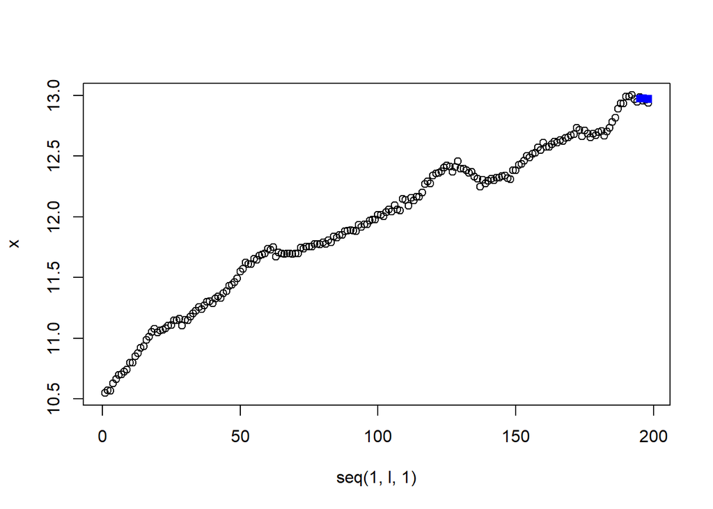

```r
x = fed_housing_data$Median_Sales_Price
l = length(x)
plot(seq(1,l,1),x,type="b")
points(seq(l-h.short+1,l,1),pred$Prediction,type="b",pch=15,col="blue")
```

The short term ASE was 81.8 M. This was slightly better than the ARIMA model. Note that it is like our other ASEs, where it compares to the unlogged, original Medium Sales Prices.

```r
file_path = "https://raw.githubusercontent.com/aabromowitz/TimeSeriersProject/refs/heads/main/LSTM_metrics_short_term.csv"
ase <- read.csv(file_path, header = TRUE)
ase
```

```
##   Metric    Value
## 1    ASE 81.81499
```

The long term prediction was the following:

```r
file_path = "https://raw.githubusercontent.com/aabromowitz/TimeSeriersProject/refs/heads/main/LSTM_predictions_long_term.csv"
pred <- read.csv(file_path, header = TRUE)
pred
```

```
##     X Prediction   Actual        Error
## 1   0   12.70576 12.67106  0.034692764
## 2   1   12.70608 12.69802  0.008055687
## 3   2   12.72127 12.70381  0.017460823
## 4   3   12.73490 12.66697  0.067928314
## 5   4   12.72078 12.70046  0.020320892
## 6   5   12.72533 12.73257 -0.007248879
## 7   6   12.74889 12.77987 -0.030979156
## 8   7   12.79208 12.81530 -0.023219109
## 9   8   12.83588 12.88715 -0.051267624
## 10  9   12.89563 12.93362 -0.037988663
## 11 10   12.94953 12.93241  0.017118454
## 12 11   12.96874 12.98929 -0.020545006
## 13 12   12.99935 12.98997  0.009381294
## 14 13   13.01107 13.00042  0.010648727
## 15 14   13.01676 12.96921  0.047543526
## 16 15   12.99711 12.94443  0.052679062
## 17 16   12.96769 12.98402 -0.016334534
## 18 17   12.97404 12.95560  0.018435478
## 19 18   12.96841 12.96407  0.004336357
## 20 19   12.97093 12.93483  0.036101340
```

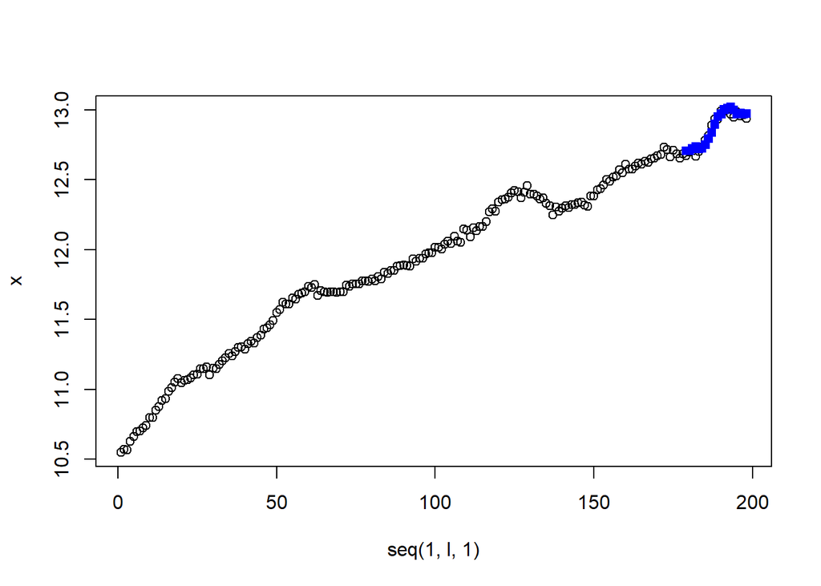

```r
plot(seq(1,l,1),x,type="b")
points(seq(l-h.long+1,l,1),pred$Prediction,type="b",pch=15,col="blue")
```

The long term ASE was 149 M. This was an order of magnitude better than the Signal Plus Noise model, which had the best long term ASE so far. And the plot of the predictions (of the logged data) vs the actual values seems to line up almost exactly.

```r
file_path = "https://raw.githubusercontent.com/aabromowitz/TimeSeriersProject/refs/heads/main/LSTM_metrics_long_term.csv"
ase <- read.csv(file_path, header = TRUE)
ase
```

```
##   Metric    Value
## 1    ASE 149.8804
```

## TFT

TFT (Temporal Fusion Transformer) is an algorithm that uses Transformers and Attention to forecast Time Series data. The model is known for being able to do very well with non-linear data, when it has tens of thousands or even hundreds of thousands of training examples. We have less than 1000, so it is unlikely to do well on this dataset.

The TFT was created in Python. The code is below.

```python
# https://unit8co.github.io/darts/generated_api/darts.models.forecasting.tft_model.html#darts.models.forecasting.tft_model.TFTModel

# from darts.datasets import WeatherDataset
from darts.models import TFTModel
from darts import TimeSeries
from darts.explainability.tft_explainer import TFTExplainer
import matplotlib.pyplot as plt
import numpy as np
import pandas as pd


# series = WeatherDataset().load()
series = pd.read_csv('https://raw.githubusercontent.com/aabromowitz/TimeSeriersProject/refs/heads/main/fed_housing_data.csv')

# Convert 'Year_Quarter' to datetime
# import pdb
# pdb.set_trace()
# series['Year_Quarter'] = pd.to_datetime(series['Year_Quarter'], format='%Y-Q%q')  # Adjust format as needed
series['Year_Quarter'] = pd.to_datetime(series['Year_Quarter'])

# Convert pandas Series/DataFrames to Darts TimeSeries
# Assuming 'Year_Quarter' is your time index
# First set the index to Year_Quarter
series = series.set_index('Year_Quarter')

# predicting atmospheric pressure
# target = series['p (mbar)'][:100]
h_short = 4
h_long = 20
# import pdb
# pdb.set_trace()
target = TimeSeries.from_dataframe(series[['Median_Sales_Price']][:-h_short])  # All data except last h_short entries

# optionally, past observed rainfall (pretending to be unknown beyond index 100)
# import pdb
# pdb.set_trace()
past_cov = TimeSeries.from_dataframe(series[['Ownership_Rate','Housing_Units_Completed','Supply_New_Houses','Housing_Price_Index']][:-h_short])

# future temperatures (pretending this component is a forecast)
# future_cov = series['T (degC)'][:106]

# by default, TFTModel is trained using a `QuantileRegression` making it a probabilistic forecasting model
# input_chunk_length = 12
input_chunk_length = 8
# n_epochs = 5
# n_epochs = 200
n_epochs = 20
random_state = 42
model = TFTModel(
    # input_chunk_length=8,
    input_chunk_length=input_chunk_length,
    output_chunk_length=h_short,
    hidden_size=128,              # Larger hidden size for more capacity
    lstm_layers=2,                # More LSTM layers
    num_attention_heads=4,        # More attention heads
    dropout=0.1,                  # Some dropout for regularization
    batch_size=16,                # Smaller batch size since we have limited data
    n_epochs=n_epochs,
    # learning_rate=0.001,          # Standard learning rate, ValueError: Invalid model creation parameters. Model `TFTModel` has no args/kwargs `['learning_rate']`
    random_state=random_state
)

# future_covariates are mandatory for `TFTModel`
# import pdb
# pdb.set_trace()
# future_cov = TimeSeries.from_dataframe(series[['Year_Quarter']])
# future_cov = TimeSeries.from_dataframe(series.iloc[:, 0])
future_cov = TimeSeries.from_dataframe(series.iloc[:, [0]])
model.fit(target, past_covariates=past_cov, future_covariates=future_cov)

# TFTModel is probabilistic by definition; using `num_samples >> 1` to generate probabilistic forecasts
# pred = model.predict(h_short, num_samples=1000)

# Get mean prediction
# mean_pred = pred.mean()

# Get quantiles if you want confidence intervals
# quantiles_pred = pred.quantile([0.025, 0.975])  # 95% confidence interval
# import pdb
# pdb.set_trace()
# quantiles_pred = pred.quantile([0.025, 0.975])  # 95% confidence interval
# quantiles_pred_1 = pred.quantile(0.025)
# quantiles_pred_2 = pred.quantile(0.975)

def evaluate_model(model, h):
    """
    Evaluate the TFT model using multiple metrics
    """
    # Make predictions
    # predictions = model.predict(n=h_short, num_samples=100)
    predictions = model.predict(n=h, num_samples=1000)
    mean_predictions = predictions.mean()

    # Get confidence intervals
    # confidence_intervals = predictions.quantiles([0.025, 0.975])
    lower_bound = predictions.quantile(0.025)  # 2.5th percentile
    upper_bound = predictions.quantile(0.975)  # 97.5th percentile

    # Get actual values (last h_short values)
    # actuals = target[-h_short:]
    actuals = TimeSeries.from_dataframe(series[['Median_Sales_Price']][-h:])

    # Convert to numpy arrays for calculations
    pred_values = mean_predictions.values()
    actual_values = actuals.values()
    lower_values = lower_bound.values()
    upper_values = upper_bound.values()

    # Calculate metrics
    total_se = 0
    n = len(pred_values)
    predictions_list = []
    actuals_list = []
    lower_bounds_list = []
    upper_bounds_list = []

    for i in range(n):
        pred = pred_values[i][0]  # Assuming single-variable predictions
        actual = actual_values[i][0]
        lower = lower_values[i][0]
        upper = upper_values[i][0]

        # Store predictions and actuals
        predictions_list.append(pred)
        actuals_list.append(actual)
        lower_bounds_list.append(lower)
        upper_bounds_list.append(upper)

        # Then un-log transform
        pred = np.exp(pred)
        actual = np.exp(actual)

        # Calculate squared error
        se = (pred - actual) ** 2
        total_se += se

    # Calculate average squared error
    ase = total_se / 1e6 /n if n > 0 else 0

    return predictions_list, actuals_list, lower_bounds_list, upper_bounds_list, ase

# Use the evaluation function
preds, acts, lower_bounds, upper_bounds, ase = evaluate_model(model, h_short)

# Print results
print(f"Average Squared Error for short term prediction: {ase:,.2f}")
print("\nPredictions vs Actuals with 95% Confidence Intervals:")
for i, (p, a, l, u) in enumerate(zip(preds, acts, lower_bounds, upper_bounds)):
    print(f"Period {i+1}:")
    print(f"  Predicted = {p:,.2f} [{l:,.2f}, {u:,.2f}]")
    print(f"  Actual    = {a:,.2f}")
    print(f"  Diff      = {abs(p-a):,.2f}")
    print(f"  Width CI  = {u-l:,.2f}")

# Optional: Calculate additional metrics
# mape_score = mape(target[-h_short:], model.predict(n=h_short).mean())
# print(f"\nMAPE: {mape_score:.2%}")

# After training the model
# static_covariates = None  # If you have any static covariates, include them here

def save_detailed_results(preds, acts, lower_bounds, upper_bounds, ase, model_name="short_term"):
    # Predictions DataFrame
    results_df = pd.DataFrame({
        'Predicted': preds,
        'Actual': acts,
        'Lower_Bound': lower_bounds,
        'Upper_Bound': upper_bounds,
        'Absolute_Error': np.abs(np.array(preds) - np.array(acts)),
        'Squared_Error': (np.array(preds) - np.array(acts))**2,
        'CI_Width': np.array(upper_bounds) - np.array(lower_bounds),
        'Within_CI': (np.array(acts) >= np.array(lower_bounds)) &
                    (np.array(acts) <= np.array(upper_bounds))
    })

    # Calculate summary metrics
    metrics_df = pd.DataFrame({
        'Metric': ['ASE', 'MAE', 'RMSE', 'Mean_CI_Width', 'Coverage_Rate'],
        'Value': [
            ase,
            np.mean(np.abs(np.array(preds) - np.array(acts))),
            np.sqrt(np.mean((np.array(preds) - np.array(acts))**2)),
            np.mean(np.array(upper_bounds) - np.array(lower_bounds)),
            np.mean((np.array(acts) >= np.array(lower_bounds)) &
                   (np.array(acts) <= np.array(upper_bounds)))
        ]
    })

    # Save both files
    results_df.to_csv(f'predictions_detailed_{model_name}.csv', index=True)
    metrics_df.to_csv(f'metrics_detailed_{model_name}.csv', index=False)

    print(f"Detailed results saved to predictions_detailed_{model_name}.csv and metrics_detailed_{model_name}.csv")

save_detailed_results(preds, acts, lower_bounds, upper_bounds, ase, model_name="TFT_short_term")

# Get interpretability components
# interpretability = model.interpret_output(
# import pdb
# pdb.set_trace()
# interpretability = model.interpret(target,past_covariates=past_cov,future_covariates=future_cov,static_covariates=static_covariates)
explainer = TFTExplainer(model)
results = explainer.explain()

# Save the variable selection plot
# plt.figure(figsize=(12, 8))
explainer.plot_variable_selection(results)
# plt.savefig('variable_importance_short.png')  # Save to file
# plt.close()  # Close the plot to free memory

# Try with long term predictions as well
# import pdb
# pdb.set_trace()
target = TimeSeries.from_dataframe(series[['Median_Sales_Price']][:-h_long])
past_cov = TimeSeries.from_dataframe(series[['Ownership_Rate','Housing_Units_Completed','Supply_New_Houses','Housing_Price_Index']][:-h_long])
model = TFTModel(
    # input_chunk_length=8,
    input_chunk_length=input_chunk_length,
    output_chunk_length=h_long,
    hidden_size=128,              # Larger hidden size for more capacity
    lstm_layers=2,                # More LSTM layers
    num_attention_heads=4,        # More attention heads
    dropout=0.1,                  # Some dropout for regularization
    batch_size=16,                # Smaller batch size since we have limited data
    n_epochs=n_epochs,
    # learning_rate=0.001,        # Standard learning rate, ValueError: Invalid model creation parameters. Model `TFTModel` has no args/kwargs `['learning_rate']`
    random_state=random_state
)
model.fit(target, past_covariates=past_cov, future_covariates=future_cov)
preds, acts, lower_bounds, upper_bounds, ase = evaluate_model(model, h_long)
print(f"Average Squared Error for long term prediction: {ase:,.2f}")
print("\nPredictions vs Actuals with 95% Confidence Intervals:")
for i, (p, a, l, u) in enumerate(zip(preds, acts, lower_bounds, upper_bounds)):
    print(f"Period {i+1}:")
    print(f"  Predicted = {p:,.2f} [{l:,.2f}, {u:,.2f}]")
    print(f"  Actual    = {a:,.2f}")
    print(f"  Diff      = {abs(p-a):,.2f}")
    print(f"  Width CI  = {u-l:,.2f}")
save_detailed_results(preds, acts, lower_bounds, upper_bounds, ase, model_name="TFT_long_term")
explainer = TFTExplainer(model)
results = explainer.explain()
explainer.plot_variable_selection(results)
```

The short term prediction was the following:

```r
file_path = "https://raw.githubusercontent.com/aabromowitz/TimeSeriersProject/refs/heads/main/predictions_detailed_TFT_short_term.csv"
pred <- read.csv(file_path, header = TRUE)
pred
```

```
##   X Predicted   Actual Lower_Bound Upper_Bound Absolute_Error Squared_Error
## 1 0  12.66963 12.98402    11.89675    13.02597      0.3143873    0.09883936
## 2 1  12.66474 12.95560    11.81557    13.04598      0.2908556    0.08459696
## 3 2  12.66228 12.96407    11.70568    13.03513      0.3017937    0.09107942
## 4 3  12.68728 12.93483    11.96067    13.03658      0.2475483    0.06128015
##   CI_Width Within_CI
## 1 1.129227      True
## 2 1.230405      True
## 3 1.329448      True
## 4 1.075911      True
```

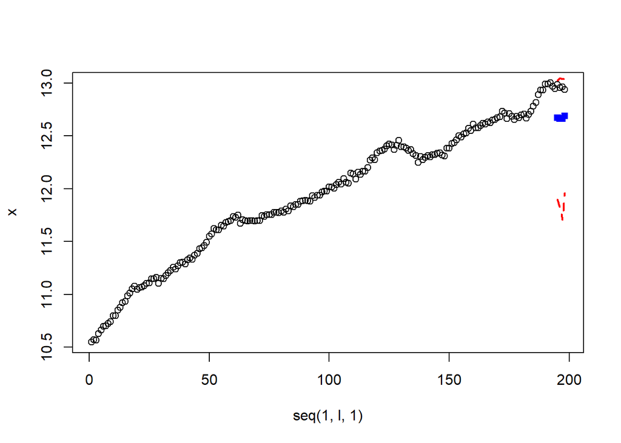

```r
h.short = 4
x = fed_housing_data$Median_Sales_Price
l = length(x)
plot(seq(1,l,1),x,type="b")
points(seq(l-h.short+1,l,1),pred$Predicted,type="b",pch=15,col="blue")
lines(seq(l-h.short+1,l,1),pred$Lower_Bound,lty=2, col="red", lwd=2)
lines(seq(l-h.short+1,l,1),pred$Upper_Bound,lty=2, col="red", lwd=2)
```

The short term ASE was 11.5 B. This was significantly worse than other models. The poor results aren’t unexpected though, as there were so few data points to train on.

```r
file_path = "https://raw.githubusercontent.com/aabromowitz/TimeSeriersProject/refs/heads/main/metrics_detailed_TFT_short_term.csv"
metrics <- read.csv(file_path, header = TRUE)
metrics # 1146
```

```
##          Metric        Value
## 1           ASE 1.145680e+04
## 2           MAE 2.886462e-01
## 3          RMSE 2.897395e-01
## 4 Mean_CI_Width 1.191248e+00
## 5 Coverage_Rate 1.000000e+00
```

The long term prediction was the following:

```r
file_path = "https://raw.githubusercontent.com/aabromowitz/TimeSeriersProject/refs/heads/main/predictions_detailed_TFT_long_term.csv"
pred <- read.csv(file_path, header = TRUE)
pred
```

```
##     X Predicted   Actual Lower_Bound Upper_Bound Absolute_Error Squared_Error
## 1   0  12.43832 12.67106    12.21089    12.75497      0.2327429    0.05416924
## 2   1  12.47469 12.69802    12.23497    12.76391      0.2233344    0.04987824
## 3   2  12.49115 12.70381    12.24657    12.83910      0.2126641    0.04522604
## 4   3  12.48697 12.66697    12.24163    12.80761      0.1800009    0.03240032
## 5   4  12.49683 12.70046    12.24852    12.83739      0.2036384    0.04146860
## 6   5  12.49251 12.73257    12.24345    12.83757      0.2400679    0.05763260
## 7   6  12.49833 12.77987    12.25592    12.81032      0.2815470    0.07926873
## 8   7  12.50507 12.81529    12.25759    12.82373      0.3102269    0.09624075
## 9   8  12.49876 12.88715    12.25309    12.81391      0.3883918    0.15084819
## 10  9  12.50641 12.93362    12.27013    12.77429      0.4272105    0.18250879
## 11 10  12.51155 12.93241    12.26884    12.82441      0.4208647    0.17712707
## 12 11  12.51987 12.98929    12.26915    12.78959      0.4694197    0.22035481
## 13 12  12.53635 12.98997    12.27686    12.85769      0.4536235    0.20577428
## 14 13  12.53622 13.00042    12.27722    12.84829      0.4642035    0.21548488
```

[output cut: 27 more lines]

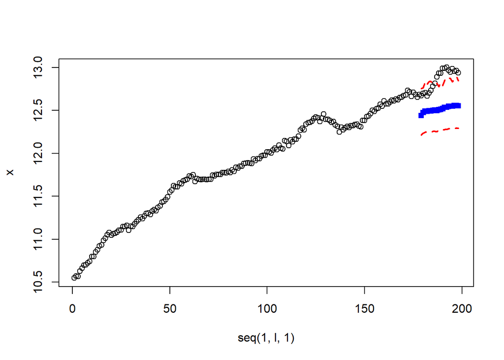

```r
h.long=20
x = fed_housing_data$Median_Sales_Price
l = length(x)
plot(seq(1,l,1),x,type="b")
points(seq(l-h.long+1,l,1),pred$Predicted,type="b",pch=15,col="blue")
lines(seq(l-h.long+1,l,1),pred$Lower_Bound,lty=2, col="red", lwd=2)
lines(seq(l-h.long+1,l,1),pred$Upper_Bound,lty=2, col="red", lwd=2)
```

The long term ASE was 15.0 B. Similar to the short term predictions, this model did very poorly compared to the other models.

```r
file_path = "https://raw.githubusercontent.com/aabromowitz/TimeSeriersProject/refs/heads/main/metrics_detailed_TFT_long_term.csv"
metrics <- read.csv(file_path, header = TRUE)
metrics # 1146
```

```
##          Metric        Value
## 1           ASE 1.498351e+04
## 2           MAE 3.477784e-01
## 3          RMSE 3.611591e-01
## 4 Mean_CI_Width 5.635607e-01
## 5 Coverage_Rate 4.000000e-01
```